# H2H T4 Scoring and Summaries

Last Updated

April 30, 2021 06:48:41 PM EDT

# T4 Follow-Up Rate

|  | In Window (N=1) | Window Period Over (N=511) | Overall (N=512) |
| --- | --- | --- | --- |
| T4 Complete |  |  |  |
| Yes | 1 (100%) | 412 (80.6%) | 413 (80.7%) |
| No | 0 (0%) | 99 (19.4%) | 99 (19.3%) |

# Demographics

## Monthly Income

| fu4_income | n | Percent |
| --- | --- | --- |
| Less than $1,000 | 316 | 76.3 |
| $1,000 - $2,500 | 75 | 18.1 |
| $2501 - $5,000 | 13 | 3.1 |
| $5,001 - $10,000 | 3 | 0.7 |
| $10,001 - $25,000 | 1 | 0.2 |
| Don’t Know | 5 | 1.2 |
| NA | 1 | 0.2 |

## Current Employment

| fu4_cemp | n | Percent |
| --- | --- | --- |
| Working full-time on the books | 12 | 2.9 |
| Working full-time off the books | 1 | 0.2 |
| Working part-time on the books | 12 | 2.9 |
| Working part-time off the books | 15 | 3.6 |
| Unemployed, looking for work | 114 | 27.5 |
| Unemployed, not looking for work | 127 | 30.7 |
| Retired | 9 | 2.2 |
| Disabled, either permanently or temporarily | 116 | 28.0 |
| Student | 5 | 1.2 |
| Other | 1 | 0.2 |
| Don’t Know | 1 | 0.2 |
| NA | 1 | 0.2 |

## Are you currently pregnant?

| fu4_pregnow | n | Percent |
| --- | --- | --- |
| No | 122 | 29.5 |
| Yes | 4 | 1.0 |
| NA | 288 | 69.6 |

## Since your last interview, how often did you run out of money for basic necessities like rent, utilities or food?

| fu4_necess | n | Percent |
| --- | --- | --- |
| Never | 120 | 29.0 |
| Daily | 24 | 5.8 |
| Weekly | 58 | 14.0 |
| Monthly | 72 | 17.4 |
| Occasionally | 137 | 33.1 |
| Don’t Know | 2 | 0.5 |
| NA | 1 | 0.2 |

## Public Assistance

| Assistance | Count | Percent |
| --- | --- | --- |
| Medical Care (e.g. Medicaid, Medicare, etc.) | 398 | 96.4 |
| Food Stamps (SNAP) | 377 | 91.3 |
| HASA Housing | 318 | 77.0 |
| Rent Assistance | 208 | 50.4 |
| Cash Assistance | 185 | 44.8 |
| SSI/ Social Security Income | 164 | 39.7 |
| SSD/ Social Security Disability | 83 | 20.1 |
| Temporary Assistance (TA) | 77 | 18.6 |
| ADAP | 25 | 6.1 |
| Other | 13 | 3.1 |
| WIC | 3 | 0.7 |
| Child Care Vouchers | 1 | 0.2 |

## Are you covered by health insurance or some other kind of health care plan?

| fu4_healthinsur_1 | n | Percent |
| --- | --- | --- |
| No | 11 | 2.7 |
| Yes | 402 | 97.1 |
| NA | 1 | 0.2 |

## What kind of health insurance or health care coverage do you have?

| fu4_healthinsur_2 | n | Percent |
| --- | --- | --- |
| Private health insurance | 2 | 0.5 |
| Medicaid managed care | 50 | 12.1 |
| Medicaid (for individuals with low incomes) | 322 | 77.8 |
| Medicare (for the elderly and people with disabilities) | 24 | 5.8 |
| Military health care (VA/TRICARE/CHAMPVA) | 1 | 0.2 |
| Other | 2 | 0.5 |
| Don’t know | 1 | 0.2 |
| NA | 12 | 2.9 |

## If Other: What is the name of the specific health insurance plan you are covered by?

| fu4_healthinsur_3 |
| --- |
| Ryan White |
| ADAP |

## Are you currently enrolled in the AIDS Drug Assistance Program, or ADAP?

| fu4_adap | n | Percent |
| --- | --- | --- |
| No | 382 | 92.3 |
| Yes | 29 | 7.0 |
| Don’t Know | 2 | 0.5 |
| NA | 1 | 0.2 |

## Do you receive services or benefits from the New York City HASA, the local HIV/AIDS Services Administration?

| fu4_hasa | n | Percent |
| --- | --- | --- |
| No | 75 | 18.1 |
| Yes | 338 | 81.6 |
| NA | 1 | 0.2 |

## What type of place do you currently live in?

| fu4_livingsit_1 | n | Percent |
| --- | --- | --- |
| Have own home or apartment (rent or own, including HASA and Section 8) | 265 | 64.0 |
| Staying at home of family member(s) | 13 | 3.1 |
| Staying at home of friend(s)/other | 6 | 1.4 |
| Group/foster home | 1 | 0.2 |
| In a rooming, boarding, or halfway house | 8 | 1.9 |
| Shelter | 106 | 25.6 |
| On the street(s) (vacant lot, abandoned building, park, etc.) | 1 | 0.2 |
| Other | 13 | 3.1 |
| NA | 1 | 0.2 |

## If Other, please specify:

| fu4_livingsit_1_other |
| --- |
| scattersite |
| congregate housing |
| nursing home |
| Independent Affordable Living Nursing Home |
| YMCA |
| congregate - supportive |
| assisted living |
| nursing home |
| SRO |
| nursing home |
| supportive housing |
| nursing home |
| nursing home |

## Do you receive on-going rental assistance from HASA, the local HIV/AIDS Services Administration?

| fu4_livingsit_2 | n | Percent |
| --- | --- | --- |
| No | 81 | 19.6 |
| Yes | 331 | 80.0 |
| Don’t Know | 1 | 0.2 |
| NA | 1 | 0.2 |

## How many individuals are living in your household, including yourself?

| fu4_livingsit_3 | n | Percent |
| --- | --- | --- |
| 0 | 1 | 0.2 |
| 1 | 316 | 76.3 |
| 2 | 59 | 14.3 |
| 3 | 22 | 5.3 |
| 4 | 6 | 1.4 |
| 5 | 4 | 1.0 |
| 6 | 2 | 0.5 |
| 7 | 2 | 0.5 |
| 11 | 1 | 0.2 |
| NA | 1 | 0.2 |

## Since your last interview, have you been homeless at any time? By homeless, we mean living on the street, in a shelter, in a Single Room Occupancy (SRO) hotel, or in a car.

| fu4_homeless_nhbs_2 | n | Percent |
| --- | --- | --- |
| No | 276 | 66.7 |
| Yes | 137 | 33.1 |
| NA | 1 | 0.2 |

## Are you currently homeless?

| fu4_homeless_nhbs_3 | n | Percent |
| --- | --- | --- |
| No | 29 | 21.2 |
| Yes | 108 | 78.8 |

# HIV and ART History

## Since your last interview, have you received health care for your HIV infection?

| fu4_hiv_art_hist_q13 | n | Percent |
| --- | --- | --- |
| No | 33 | 8.0 |
| Yes | 380 | 91.8 |
| NA | 1 | 0.2 |

## In what type of place did you receive most of your HIV care since your last interview?

| fu4_hiv_art_hist_q14 | n | Percent |
| --- | --- | --- |
| Community-based clinic | 191 | 46.1 |
| Emergency room | 2 | 0.5 |
| Clinic located in a hospital | 169 | 40.8 |
| Private doctor’s office | 17 | 4.1 |
| Other | 1 | 0.2 |
| NA | 34 | 8.2 |

## If Other, please specify:

| fu4_hiv_art_hist_q14_1 |
| --- |
| Virtual sessions during COVID-19 |

## What is the name of this place?

| fu4_hiv_art_hist_q15 | n | Percent |
| --- | --- | --- |
| Housing Works | 33 | 8.7 |
| Brightpoint Health | 18 | 4.7 |
| Montefiore | 12 | 3.2 |
| Harlem Hospital | 11 | 2.9 |
| Lincoln Hospital | 7 | 1.8 |
| Mt Sinai | 7 | 1.8 |
| Bronx Lebanon | 6 | 1.6 |
| Callen Lorde | 6 | 1.6 |
| Harlem United | 5 | 1.3 |
| NY Presbyterian | 5 | 1.3 |
| Columbia Presbyterian | 4 | 1.1 |
| Jack Martin Clinic | 4 | 1.1 |
| AHF | 3 | 0.8 |
| Bellevue Hospital | 3 | 0.8 |
| Brightpoint | 3 | 0.8 |
| housing works | 3 | 0.8 |
| Jacobi | 3 | 0.8 |
| Jacobi Medical Center | 3 | 0.8 |
| montefiori | 3 | 0.8 |
| Mount Sinai | 3 | 0.8 |
| Mt Sinai West | 3 | 0.8 |
| Mt. Sinai | 3 | 0.8 |
| Peter Krueger Clinic | 3 | 0.8 |
| Presbyterian Hospital | 3 | 0.8 |
| -999 | 2 | 0.5 |
| ACQC | 2 | 0.5 |
| brightpoint health | 2 | 0.5 |
| Brooklyn Hospital | 2 | 0.5 |
| Casa Maria | 2 | 0.5 |
| Community Healthcare Network | 2 | 0.5 |

[output cut: 201 more lines]

## Since your last interview, have you received care from a health care provider who specializes in treating HIV?

| fu4_hiv_art_hist_q16 | n | Percent |
| --- | --- | --- |
| No | 17 | 4.1 |
| Yes | 356 | 86.0 |
| Don’t Know | 7 | 1.7 |
| NA | 34 | 8.2 |

## Is there one particular doctor, nurse or other medical provider who you usually see for most of your HIV treatment, like CD4 and viral load tests?

| fu4_hiv_art_hist_q17 | n | Percent |
| --- | --- | --- |
| No | 21 | 5.1 |
| Yes | 357 | 86.2 |
| Don’t Know | 2 | 0.5 |
| NA | 34 | 8.2 |

## Think about your most recent HIV health care appointment. What was your CD4 or T cell count the last time you received it? Please type the number.

| n | Mean | sd | Median | IQR | Min | Max |
| --- | --- | --- | --- | --- | --- | --- |
| 197 | 484 | 352 | 415 | 542 | 0 | 1600 |

## When was your last CD4 or T cell count taken?

| fu4_hiv_art_hist_q19 | n | Percent |
| --- | --- | --- |
| Less than 1 month ago | 135 | 32.6 |
| Between 1 month but less than 6 months ago | 216 | 52.2 |
| Between 6 months and 12 months ago | 18 | 4.3 |
| Don’t Know | 11 | 2.7 |
| NA | 34 | 8.2 |

## What was your viral load count the last time you received it?

| fu4_hiv_art_hist_q20 | n | Percent |
| --- | --- | --- |
| Undetectable | 136 | 32.9 |
| 50 - 10,000 copies/mL | 52 | 12.6 |
| 10,001 - 30,000 copies/mL | 14 | 3.4 |
| 30,001 - 100,000 copies/mL | 9 | 2.2 |
| 100,001 - 500,000 copies/mL | 6 | 1.4 |
| More than 500,000 copies/mL | 5 | 1.2 |
| Don’t Know | 158 | 38.2 |
| NA | 34 | 8.2 |

## When was your last viral load taken?

| fu4_hiv_art_hist_q21 | n | Percent |
| --- | --- | --- |
| Less than 1 month ago | 136 | 32.9 |
| Between 1 month but less than 6 months ago | 212 | 51.2 |
| Between 6 months and 12 months ago | 19 | 4.6 |
| Don’t Know | 13 | 3.1 |
| NA | 34 | 8.2 |

## Since your last interview, have you been hospitalized as a result of HIV infection or the consequences of HIV?

| fu4_hiv_art_hist_q22 | n | Percent |
| --- | --- | --- |
| No | 369 | 89.1 |
| Yes | 42 | 10.1 |
| Don’t Know | 2 | 0.5 |
| NA | 1 | 0.2 |

## Since your last interview, have you been to an ER (emergency room) as a result of HIV infection or the consequences of HIV?

| fu4_hiv_art_hist_q23 | n | Percent |
| --- | --- | --- |
| No | 366 | 88.4 |
| Yes | 45 | 10.9 |
| Don’t Know | 2 | 0.5 |
| NA | 1 | 0.2 |

## How many different health care providers have you seen for your **physical health** since your last interview, other than the provider who treats your HIV infection?

| fu4_hiv_art_hist_q24 | n | Percent |
| --- | --- | --- |
| -999 | 1 | 0.2 |
| 0 | 224 | 54.1 |
| 1 | 107 | 25.8 |
| 2 | 40 | 9.7 |
| 3 | 25 | 6.0 |
| 4 | 11 | 2.7 |
| 6 | 2 | 0.5 |
| 7 | 1 | 0.2 |
| 8 | 1 | 0.2 |
| 12 | 1 | 0.2 |
| NA | 1 | 0.2 |

## How many different health care providers have you seen for your **mental health** since your last interview, other than the provider who treats your HIV infection?

| fu4_hiv_art_hist_q25 | n | Percent |
| --- | --- | --- |
| -999 | 1 | 0.2 |
| 0 | 256 | 61.8 |
| 1 | 119 | 28.7 |
| 2 | 32 | 7.7 |
| 3 | 5 | 1.2 |
| NA | 1 | 0.2 |

## Since your last interview, not including any medications for HIV infection, how many different medications do you take (not including herbal supplements)?

| fu4_hiv_art_hist_q26 | n | Percent |
| --- | --- | --- |
| -999 | 1 | 0.2 |
| 0 | 122 | 29.5 |
| 1 | 67 | 16.2 |
| 2 | 60 | 14.5 |
| 3 | 56 | 13.5 |
| 4 | 32 | 7.7 |
| 5 | 19 | 4.6 |
| 6 | 9 | 2.2 |
| 7 | 19 | 4.6 |
| 8 | 9 | 2.2 |
| 9 | 5 | 1.2 |
| 10 | 5 | 1.2 |
| 11 | 1 | 0.2 |
| 13 | 2 | 0.5 |
| 15 | 3 | 0.7 |
| 17 | 1 | 0.2 |
| 20 | 1 | 0.2 |
| 23 | 1 | 0.2 |
| NA | 1 | 0.2 |

## Please look through the HIV medications chart. Since your last interview, have you taken any HIV medications such as AZT, a protease inhibitor, or any other drugs such as those listed on this card?

| fu4_hiv_art_hist_q27 | n | Percent |
| --- | --- | --- |
| No | 38 | 9.2 |
| Yes | 374 | 90.3 |
| Don’t Know | 1 | 0.2 |
| NA | 1 | 0.2 |

## Thinking only about the time since your last interview, when did you first take any of these HIV medications? Number of weeks ago.

| n | Mean | sd | Median | IQR | Min | Max |
| --- | --- | --- | --- | --- | --- | --- |
| 266 | 105 weeks | 208 | 36 weeks | 65 | 2 weeks | 1428 weeks |

- Note: Some participants are reporting more weeks than the total number of weeks since their last interview.

## Did you stop taking these HIV medications at any time since the last interview?

| fu4_hiv_art_hist_q28b | n | Percent |
| --- | --- | --- |
| No | 231 | 55.8 |
| Yes | 142 | 34.3 |
| Don’t Know | 1 | 0.2 |
| NA | 40 | 9.7 |

## Are you currently taking these medications?

| fu4_hiv_art_hist_q28c | n | Percent |
| --- | --- | --- |
| No | 35 | 8.5 |
| Yes | 339 | 81.9 |
| NA | 40 | 9.7 |

## When you were taking HIV medications in the time since your last interview; how long did you keep taking them before either stopping it or having to switch to another regimen? (Choose one)

| fu4_hiv_art_hist_q29 | n | Percent |
| --- | --- | --- |
| Less than 1 month | 53 | 12.8 |
| Between 1 month but less than 6 months | 75 | 18.1 |
| Between 6 months and 12 months | 7 | 1.7 |
| More than 12 months | 3 | 0.7 |
| Don’t Know | 4 | 1.0 |
| NA | 272 | 65.7 |

## People sometimes start HIV medication, then stop and take a break, and then try again. Thinking only about the time since your last interview, how many different times have you started to take HIV medication, whether you took it for a long time period or a short time since your last interview? Please type the number.

| fu4_hiv_art_hist_q30 | n | Percent |
| --- | --- | --- |
| -999 | 9 | 2.2 |
| 0 | 208 | 50.2 |
| 1 | 71 | 17.1 |
| 2 | 23 | 5.6 |
| 3 | 21 | 5.1 |
| 4 | 15 | 3.6 |
| 5 | 10 | 2.4 |
| 6 | 4 | 1.0 |
| 7 | 1 | 0.2 |
| 8 | 3 | 0.7 |
| 10 | 6 | 1.4 |
| 12 | 2 | 0.5 |
| 100 | 1 | 0.2 |
| NA | 40 | 9.7 |

## What is the longest amount of time you took a regimen of HIV medication since your last interview? (Provide answer in months. Enter 0 if less than 1 month.)

| fu4_hiv_art_hist_q31 | n | Percent |
| --- | --- | --- |
| -999 | 7 | 1.7 |
| 0 | 30 | 7.2 |
| 1 | 50 | 12.1 |
| 2 | 48 | 11.6 |
| 3 | 65 | 15.7 |
| 4 | 83 | 20.0 |
| 5 | 29 | 7.0 |
| 6 | 30 | 7.2 |
| 7 | 13 | 3.1 |
| 9 | 3 | 0.7 |
| 10 | 2 | 0.5 |
| 11 | 1 | 0.2 |
| 12 | 9 | 2.2 |
| 13 | 1 | 0.2 |
| 22 | 1 | 0.2 |
| 24 | 2 | 0.5 |
| NA | 40 | 9.7 |

- Note: Some participants are reporting more months than the total number of months since their last interview.

## When is the last time you took a dose of HIV medication? Number of weeks ago.

| n | Mean | sd | Median | IQR | Min | Max |
| --- | --- | --- | --- | --- | --- | --- |
| 372 | 3 weeks | 5 | 2 weeks | 2 | 0 weeks | 45 weeks |

## As far as you know, does your health care provider think it would be a good idea for you to start HIV medication at this time?

| fu4_hiv_art_hist_q33 | n | Percent |
| --- | --- | --- |
| Yes | 35 | 8.5 |
| NA | 379 | 91.5 |

# Reasons for stopping or discontinuing HIV medication

| Reason | Count | Percent |
| --- | --- | --- |
| You did not want side effects of the drugs. | 42 | 29.6 |
| You decided to stop because your CD4 and viral load numbers have been good. | 25 | 17.6 |
| You switched to other drugs. | 24 | 16.9 |
| You were on too many medications. | 23 | 16.2 |
| You prefer alternative treatments. | 16 | 11.3 |
| You changed doctors or clinics. | 13 | 9.2 |
| You do not want anyone to find out that you are HIV positive. | 12 | 8.5 |
| The drug(s) initially worked, but then stopped working. | 11 | 7.7 |
| Doctor told you to stop. | 6 | 4.2 |
| Could not afford the drug. | 5 | 3.5 |
| The drug(s) did not work. | 5 | 3.5 |
| You believe you have been cured of HIV. | 2 | 1.4 |
| Your partner or friends suggested you stop taking them. | 2 | 1.4 |

# Reasons for never taking HIV medication

[output not shown]

# HIV Medication Adherence

## Visual Analog Scale

- Machtinger, E. L., & Bangsberg, D. R. (2005). HIV Insite Knowledge base chapter. Aherence to HIV Antiretroviral Therapy: University of California, San Francisco.
- http://hivinsite.ucsf.edu/InSite?page=kb-03-02-09
- Giordano T, Guzman D, Clark R, Charlebois E, Bangsberg D. Measuring adherence to antiretroviral therapy in a diverse pop- ulation using a visual analogue scale. *HIV Clin Trials*. 2004;5(2):74-9.
- Walsh, J.C., Mandalia, S., & Gazzard, B.G. Responses to a 1 month self-report on adherence to antiretroviral therapy are consistent with electronic data and virological treatment outcome. *AIDS*. 2002, 16: 269-277.

### Have you been prescribed to take HIV medications within the last 30 days?

| fu4_vas_q1 | n | Percent |
| --- | --- | --- |
| No | 57 | 13.8 |
| Yes | 357 | 86.2 |

### How much medication have you taken in the last 3-4 weeks? (0-100%)

| n | Mean | sd | Median | IQR | Min | Max |
| --- | --- | --- | --- | --- | --- | --- |
| 357 | 80.8 | 27.3 | 95 | 30 | 0 | 100 |

## Case-Adherence Index

- Mannheimer, S. B., Mukherjee, R., Hirschhorn, L. R., Dougherty, J., Celano, S. A., Ciccarone, D., … & Botsko, M. (2006). The CASE adherence index: A novel method for measuring adherence to antiretroviral therapy. *AIDS care*, 18(7), 853-861.

### How often do you feel that you have difficulty taking your HIV medications on time? By ‘on time’ we mean no more than two hours before or two hours after the time your doctor told you to take it.

| fu4_case_adh_q1 | n | Percent |
| --- | --- | --- |
| Never | 159 | 46.5 |
| Rarely | 104 | 30.4 |
| Most of the time | 60 | 17.5 |
| All of the time | 19 | 5.6 |

### On average, how many days per week would you say that you missed at least one dose of your HIV medications?

| fu4_case_adh_q2 | n | Percent |
| --- | --- | --- |
| 4-6 days/week | 5 | 1.5 |
| 2-3 days/week | 74 | 21.6 |
| Once a week | 70 | 20.5 |
| Less than once a week | 59 | 17.3 |
| Never | 134 | 39.2 |

### When was the last time you missed at least one dose of your HIV medications?

| fu4_case_adh_q3 | n | Percent |
| --- | --- | --- |
| Within the past week | 107 | 31.3 |
| 1-2 weeks ago | 60 | 17.5 |
| 3-4 weeks ago | 23 | 6.7 |
| Between 1 and 3 months ago | 56 | 16.4 |
| More than 3 months ago | 42 | 12.3 |
| Never | 54 | 15.8 |

### Score (3-16)

| n | Mean | sd | Median | IQR | Min | Max |
| --- | --- | --- | --- | --- | --- | --- |
| 342 | 10.97 | 3.43 | 11 | 6 | 4 | 16 |

### Good or Poor Adherence

| Good_Poor_Adherence | n | Percent |
| --- | --- | --- |
| Good Adherence | 176 | 51.5 |
| Poor Adherence | 166 | 48.5 |

Coefficient Alpha

- **total**:

  | raw_alpha | std.alpha | G6(smc) | average_r | S/N | ase | mean | sd | median_r |
  | --- | --- | --- | --- | --- | --- | --- | --- | --- |
  | 0.7518 | 0.7836 | 0.7313 | 0.5469 | 3.621 | 0.01886 | 3.657 | 1.142 | 0.4873 |

- **alpha.drop**:

  |  | raw_alpha | std.alpha | G6(smc) | average_r | S/N | alpha se | var.r | med.r |
  | --- | --- | --- | --- | --- | --- | --- | --- | --- |
  | **fu4_case_adh_q1** | 0.7885 | 0.8297 | 0.709 | 0.709 | 4.873 | 0.0195 | NA | 0.709 |
  | **fu4_case_adh_q2** | 0.5186 | 0.6153 | 0.4444 | 0.4444 | 1.6 | 0.03922 | NA | 0.4444 |
  | **fu4_case_adh_q3** | 0.6361 | 0.6553 | 0.4873 | 0.4873 | 1.901 | 0.03718 | NA | 0.4873 |

- **item.stats**:

  |  | n | raw.r | std.r | r.cor | r.drop | mean | sd |
  | --- | --- | --- | --- | --- | --- | --- | --- |
  | **fu4_case_adh_q1** | 342 | 0.6844 | 0.7707 | 0.5547 | 0.4973 | 3.178 | 0.9128 |
  | **fu4_case_adh_q2** | 342 | 0.8766 | 0.8763 | 0.81 | 0.7323 | 4.711 | 1.231 |
  | **fu4_case_adh_q3** | 342 | 0.9197 | 0.8592 | 0.7787 | 0.6889 | 3.082 | 1.873 |

- **response.freq**:

  |  | 1 | 2 | 3 | 4 | 5 | 6 | miss |
  | --- | --- | --- | --- | --- | --- | --- | --- |
  | **fu4_case_adh_q1** | 0.05556 | 0.1754 | 0.3041 | 0.4649 | 0 | 0 | 0 |
  | **fu4_case_adh_q2** | 0 | 0.01462 | 0.2164 | 0.2047 | 0.1725 | 0.3918 | 0 |
  | **fu4_case_adh_q3** | 0.3129 | 0.1754 | 0.06725 | 0.1637 | 0.1228 | 0.1579 | 0 |

# WHO Assist

- WHO ASSIST Working Group (2002). The Alcohol, Smoking and Substance Involvement Screening Test (ASSIST): development, reliability and feasibility. *Addiction*, 97 (9): 1183-1194.
- Humeniuk RE, Ali RA, Babor TF, Farrell M, Formigoni ML, Jittiwutikarn J, Boerngen de Larcerda R, Ling W, Marsden J, Monteiro M, Nhiwhatiwa S, Pal H, Poznyak V & Simon S (2008). Validation of the Alcohol Smoking and Substance Involvement Screening Test (ASSIST). *Addiction* 103(6): 1039-1047.
- Humeniuk RE, Henry-Edwards S, Ali RL, Poznyak V and Monteiro M (2010). *The Alcohol, Smoking and Substance Involvement Screening Test (ASSIST): manual for use in primary care*. Geneva, World Health Organization.

## Ever Used

| Substance | Count | Percent |
| --- | --- | --- |
| a. Tobacco products | 286 | 69.2 |
| b. Alcoholic beverages | 201 | 48.7 |
| c. Cannabis | 196 | 47.5 |
| d. Cocaine | 106 | 25.7 |
| e. Prescription stimulants | 9 | 2.2 |
| f. Methamphetamine | 30 | 7.3 |
| g. Inhalants | 14 | 3.4 |
| h. Sedatives or sleeping pills | 25 | 6.1 |
| i. Hallucinogens | 8 | 1.9 |
| j. Prescription Opioids | 32 | 7.7 |
| k. Street opioids | 27 | 6.5 |
| l. Other | 4 | 1.0 |

## Has a friend or relative or anyone else ever expressed concern about your use

Tobacco products (cigarettes, chewing tobacco, cigars, etc.)

| fu4_who_assist_q1_lastv_a | n | Percent |
| --- | --- | --- |
| No, never | 144 | 50.3 |
| Yes, but not in the past 3 months | 53 | 18.5 |
| Yes, in the past 3 months | 89 | 31.1 |

Alcoholic beverages (beer, wine, spirits, etc.)

| fu4_who_assist_q1_lastv_b | n | Percent |
| --- | --- | --- |
| No, never | 123 | 61.2 |
| Yes, but not in the past 3 months | 33 | 16.4 |
| Yes, in the past 3 months | 45 | 22.4 |

Cannabis (marijuana, pot, grass, hash, etc.)

| fu4_who_assist_q1_lastv_c | n | Percent |
| --- | --- | --- |
| No, never | 138 | 70.4 |
| Yes, but not in the past 3 months | 27 | 13.8 |
| Yes, in the past 3 months | 31 | 15.8 |

Cocaine (coke, crack, etc.)

| fu4_who_assist_q1_lastv_d | n | Percent |
| --- | --- | --- |
| No, never | 31 | 29.2 |
| Yes, but not in the past 3 months | 24 | 22.6 |
| Yes, in the past 3 months | 51 | 48.1 |

Prescription stimulants (Ritalin, Concerta, Dexedrine, Adderall, diet pills, etc.)

| fu4_who_assist_q1_lastv_e | n | Percent |
| --- | --- | --- |
| No, never | 6 | 66.7 |
| Yes, but not in the past 3 months | 1 | 11.1 |
| Yes, in the past 3 months | 2 | 22.2 |

Methamphetamine (speed, crystal meth, ice, etc.)

| fu4_who_assist_q1_lastv_f | n | Percent |
| --- | --- | --- |
| No, never | 11 | 36.7 |
| Yes, but not in the past 3 months | 10 | 33.3 |
| Yes, in the past 3 months | 9 | 30.0 |

Inhalants (poppers, nitrous, glue, gas, paint thinner, etc.)

| fu4_who_assist_q1_lastv_g | n | Percent |
| --- | --- | --- |
| No, never | 7 | 50.0 |
| Yes, but not in the past 3 months | 6 | 42.9 |
| Yes, in the past 3 months | 1 | 7.1 |

Sedatives or sleeping pills (Valium, Ativan, Xanax, Klonopin, Librium, Rohypnol, GHB, etc.)

| fu4_who_assist_q1_lastv_h | n | Percent |
| --- | --- | --- |
| No, never | 15 | 60 |
| Yes, but not in the past 3 months | 3 | 12 |
| Yes, in the past 3 months | 7 | 28 |

Hallucinogens (Ecstasy, LSD, acid, mushrooms, PCP, Special K, etc.)

| fu4_who_assist_q1_lastv_i | n | Percent |
| --- | --- | --- |
| No, never | 5 | 62.5 |
| Yes, but not in the past 3 months | 3 | 37.5 |

Prescription Opioids

| fu4_who_assist_q1_lastv_j | n | Percent |
| --- | --- | --- |
| No, never | 17 | 53.1 |
| Yes, but not in the past 3 months | 6 | 18.8 |
| Yes, in the past 3 months | 9 | 28.1 |

Street opioids (heroin, opium, etc.)

| fu4_who_assist_q1_lastv_k | n | Percent |
| --- | --- | --- |
| No, never | 12 | 44.4 |
| Yes, but not in the past 3 months | 6 | 22.2 |
| Yes, in the past 3 months | 9 | 33.3 |

Other

| fu4_who_assist_q1_lastv_l | n | Percent |
| --- | --- | --- |
| No, never | 4 | 100 |

## Have you tried to cut down

Tobacco products (cigarettes, chewing tobacco, cigars, etc.)

| fu4_who_assist_q2_lastv_a | n | Percent |
| --- | --- | --- |
| No, never | 60 | 21.0 |
| Yes, but not in the past 3 months | 77 | 26.9 |
| Yes, in the past 3 months | 149 | 52.1 |

Alcoholic beverages (beer, wine, spirits, etc.)

| fu4_who_assist_q2_lastv_b | n | Percent |
| --- | --- | --- |
| No, never | 72 | 35.8 |
| Yes, but not in the past 3 months | 48 | 23.9 |
| Yes, in the past 3 months | 81 | 40.3 |

Cannabis (marijuana, pot, grass, hash, etc.)

| fu4_who_assist_q2_lastv_c | n | Percent |
| --- | --- | --- |
| No, never | 102 | 52.0 |
| Yes, but not in the past 3 months | 35 | 17.9 |
| Yes, in the past 3 months | 59 | 30.1 |

Cocaine (coke, crack, etc.)

| fu4_who_assist_q2_lastv_d | n | Percent |
| --- | --- | --- |
| No, never | 17 | 16.0 |
| Yes, but not in the past 3 months | 22 | 20.8 |
| Yes, in the past 3 months | 67 | 63.2 |

Prescription stimulants (Ritalin, Concerta, Dexedrine, Adderall, diet pills, etc.)

| fu4_who_assist_q2_lastv_e | n | Percent |
| --- | --- | --- |
| No, never | 5 | 55.6 |
| Yes, but not in the past 3 months | 2 | 22.2 |
| Yes, in the past 3 months | 2 | 22.2 |

Methamphetamine (speed, crystal meth, ice, etc.)

| fu4_who_assist_q2_lastv_f | n | Percent |
| --- | --- | --- |
| No, never | 10 | 33.3 |
| Yes, but not in the past 3 months | 6 | 20.0 |
| Yes, in the past 3 months | 14 | 46.7 |

Inhalants (poppers, nitrous, glue, gas, paint thinner, etc.)

| fu4_who_assist_q2_lastv_g | n | Percent |
| --- | --- | --- |
| No, never | 6 | 42.9 |
| Yes, but not in the past 3 months | 3 | 21.4 |
| Yes, in the past 3 months | 5 | 35.7 |

Sedatives or sleeping pills (Valium, Ativan, Xanax, Klonopin, Librium, Rohypnol, GHB, etc.)

| fu4_who_assist_q2_lastv_h | n | Percent |
| --- | --- | --- |
| No, never | 13 | 52 |
| Yes, but not in the past 3 months | 6 | 24 |
| Yes, in the past 3 months | 6 | 24 |

Hallucinogens (Ecstasy, LSD, acid, mushrooms, PCP, Special K, etc.)

| fu4_who_assist_q2_lastv_i | n | Percent |
| --- | --- | --- |
| No, never | 1 | 12.5 |
| Yes, but not in the past 3 months | 2 | 25.0 |
| Yes, in the past 3 months | 5 | 62.5 |

Prescription Opioids

| fu4_who_assist_q2_lastv_j | n | Percent |
| --- | --- | --- |
| No, never | 18 | 56.2 |
| Yes, but not in the past 3 months | 6 | 18.8 |
| Yes, in the past 3 months | 8 | 25.0 |

Street opioids (heroin, opium, etc.)

| fu4_who_assist_q2_lastv_k | n | Percent |
| --- | --- | --- |
| No, never | 7 | 25.9 |
| Yes, but not in the past 3 months | 5 | 18.5 |
| Yes, in the past 3 months | 15 | 55.6 |

Other

| fu4_who_assist_q2_lastv_l | n | Percent |
| --- | --- | --- |
| No, never | 3 | 75 |
| Yes, in the past 3 months | 1 | 25 |

## Any Use Past Three Months

Tobacco products (cigarettes, chewing tobacco, cigars, etc.)

| fu4_who_assist_q1_p3mth_a | n | Percent |
| --- | --- | --- |
| Never: not used in the last 3 months | 5 | 1.7 |
| Once or Twice: 1 to 2 times in the past 3 months | 15 | 5.2 |
| Monthly: Average of 1 to 3 times per month over the last 3 months | 23 | 8.0 |
| Weekly: 1 to 4 times per week | 55 | 19.2 |
| Daily or almost daily: 5 to 7 days per week | 188 | 65.7 |

Alcoholic beverages (beer, wine, spirits, etc.)

| fu4_who_assist_q1_p3mth_b | n | Percent |
| --- | --- | --- |
| Never: not used in the last 3 months | 6 | 3.0 |
| Once or Twice: 1 to 2 times in the past 3 months | 51 | 25.4 |
| Monthly: Average of 1 to 3 times per month over the last 3 months | 44 | 21.9 |
| Weekly: 1 to 4 times per week | 64 | 31.8 |
| Daily or almost daily: 5 to 7 days per week | 36 | 17.9 |

Cannabis (marijuana, pot, grass, hash, etc.)

| fu4_who_assist_q1_p3mth_c | n | Percent |
| --- | --- | --- |
| Never: not used in the last 3 months | 9 | 4.6 |
| Once or Twice: 1 to 2 times in the past 3 months | 23 | 11.7 |
| Monthly: Average of 1 to 3 times per month over the last 3 months | 26 | 13.3 |
| Weekly: 1 to 4 times per week | 57 | 29.1 |
| Daily or almost daily: 5 to 7 days per week | 81 | 41.3 |

Cocaine (coke, crack, etc.)

| fu4_who_assist_q1_p3mth_d | n | Percent |
| --- | --- | --- |
| Never: not used in the last 3 months | 4 | 3.8 |
| Once or Twice: 1 to 2 times in the past 3 months | 23 | 21.7 |
| Monthly: Average of 1 to 3 times per month over the last 3 months | 37 | 34.9 |
| Weekly: 1 to 4 times per week | 23 | 21.7 |
| Daily or almost daily: 5 to 7 days per week | 19 | 17.9 |

Prescription stimulants (Ritalin, Concerta, Dexedrine, Adderall, diet pills, etc.)

| fu4_who_assist_q1_p3mth_e | n | Percent |
| --- | --- | --- |
| Never: not used in the last 3 months | 6 | 66.7 |
| Once or Twice: 1 to 2 times in the past 3 months | 2 | 22.2 |
| Daily or almost daily: 5 to 7 days per week | 1 | 11.1 |

Methamphetamine (speed, crystal meth, ice, etc.)

| fu4_who_assist_q1_p3mth_f | n | Percent |
| --- | --- | --- |
| Never: not used in the last 3 months | 6 | 20.0 |
| Once or Twice: 1 to 2 times in the past 3 months | 9 | 30.0 |
| Monthly: Average of 1 to 3 times per month over the last 3 months | 5 | 16.7 |
| Weekly: 1 to 4 times per week | 6 | 20.0 |
| Daily or almost daily: 5 to 7 days per week | 4 | 13.3 |

Inhalants (poppers, nitrous, glue, gas, paint thinner, etc.)

| fu4_who_assist_q1_p3mth_g | n | Percent |
| --- | --- | --- |
| Never: not used in the last 3 months | 1 | 7.1 |
| Once or Twice: 1 to 2 times in the past 3 months | 4 | 28.6 |
| Monthly: Average of 1 to 3 times per month over the last 3 months | 7 | 50.0 |
| Weekly: 1 to 4 times per week | 1 | 7.1 |
| Daily or almost daily: 5 to 7 days per week | 1 | 7.1 |

Sedatives or sleeping pills (Valium, Ativan, Xanax, Klonopin, Librium, Rohypnol, GHB, etc.)

| fu4_who_assist_q1_p3mth_h | n | Percent |
| --- | --- | --- |
| Never: not used in the last 3 months | 7 | 28 |
| Once or Twice: 1 to 2 times in the past 3 months | 3 | 12 |
| Monthly: Average of 1 to 3 times per month over the last 3 months | 4 | 16 |
| Weekly: 1 to 4 times per week | 3 | 12 |
| Daily or almost daily: 5 to 7 days per week | 8 | 32 |

Hallucinogens (Ecstasy, LSD, acid, mushrooms, PCP, Special K, etc.)

| fu4_who_assist_q1_p3mth_i | n | Percent |
| --- | --- | --- |
| Never: not used in the last 3 months | 4 | 50.0 |
| Once or Twice: 1 to 2 times in the past 3 months | 1 | 12.5 |
| Monthly: Average of 1 to 3 times per month over the last 3 months | 2 | 25.0 |
| Weekly: 1 to 4 times per week | 1 | 12.5 |

Prescription Opioids

| fu4_who_assist_q1_p3mth_j | n | Percent |
| --- | --- | --- |
| Never: not used in the last 3 months | 4 | 12.5 |
| Once or Twice: 1 to 2 times in the past 3 months | 3 | 9.4 |
| Monthly: Average of 1 to 3 times per month over the last 3 months | 4 | 12.5 |
| Weekly: 1 to 4 times per week | 4 | 12.5 |
| Daily or almost daily: 5 to 7 days per week | 17 | 53.1 |

Street opioids (heroin, opium, etc.)

| fu4_who_assist_q1_p3mth_k | n | Percent |
| --- | --- | --- |
| Never: not used in the last 3 months | 7 | 25.9 |
| Once or Twice: 1 to 2 times in the past 3 months | 7 | 25.9 |
| Monthly: Average of 1 to 3 times per month over the last 3 months | 5 | 18.5 |
| Weekly: 1 to 4 times per week | 3 | 11.1 |
| Daily or almost daily: 5 to 7 days per week | 5 | 18.5 |

Other

| fu4_who_assist_q1_p3mth_l | n | Percent |
| --- | --- | --- |
| Never: not used in the last 3 months | 1 | 25 |
| Monthly: Average of 1 to 3 times per month over the last 3 months | 1 | 25 |
| Daily or almost daily: 5 to 7 days per week | 2 | 50 |

## Strong Desire of Urge to Use Past Three Months

Tobacco products (cigarettes, chewing tobacco, cigars, etc.)

| fu4_who_assist_q2_p3mth_a | n | Percent |
| --- | --- | --- |
| Never | 12 | 4.3 |
| Once or Twice: 1 to 2 times in the past 3 months | 24 | 8.5 |
| Monthly: Average of 1 to 3 times per month over the last 3 months | 21 | 7.5 |
| Weekly: 1 to 4 times per week | 61 | 21.7 |
| Daily or almost daily: 5 to 7 days per week | 163 | 58.0 |

Alcoholic beverages (beer, wine, spirits, etc.)

| fu4_who_assist_q2_p3mth_b | n | Percent |
| --- | --- | --- |
| Never | 49 | 25.1 |
| Once or Twice: 1 to 2 times in the past 3 months | 38 | 19.5 |
| Monthly: Average of 1 to 3 times per month over the last 3 months | 31 | 15.9 |
| Weekly: 1 to 4 times per week | 45 | 23.1 |
| Daily or almost daily: 5 to 7 days per week | 32 | 16.4 |

Cannabis (marijuana, pot, grass, hash, etc.)

| fu4_who_assist_q2_p3mth_c | n | Percent |
| --- | --- | --- |
| Never | 38 | 20.3 |
| Once or Twice: 1 to 2 times in the past 3 months | 19 | 10.2 |
| Monthly: Average of 1 to 3 times per month over the last 3 months | 23 | 12.3 |
| Weekly: 1 to 4 times per week | 34 | 18.2 |
| Daily or almost daily: 5 to 7 days per week | 73 | 39.0 |

Cocaine (coke, crack, etc.)

| fu4_who_assist_q2_p3mth_d | n | Percent |
| --- | --- | --- |
| Never | 6 | 5.9 |
| Once or Twice: 1 to 2 times in the past 3 months | 22 | 21.6 |
| Monthly: Average of 1 to 3 times per month over the last 3 months | 23 | 22.5 |
| Weekly: 1 to 4 times per week | 27 | 26.5 |
| Daily or almost daily: 5 to 7 days per week | 24 | 23.5 |

Prescription stimulants (Ritalin, Concerta, Dexedrine, Adderall, diet pills, etc.)

| fu4_who_assist_q2_p3mth_e | n | Percent |
| --- | --- | --- |
| Never | 1 | 33.3 |
| Monthly: Average of 1 to 3 times per month over the last 3 months | 1 | 33.3 |
| Daily or almost daily: 5 to 7 days per week | 1 | 33.3 |

Methamphetamine (speed, crystal meth, ice, etc.)

| fu4_who_assist_q2_p3mth_f | n | Percent |
| --- | --- | --- |
| Never | 1 | 4.2 |
| Once or Twice: 1 to 2 times in the past 3 months | 4 | 16.7 |
| Monthly: Average of 1 to 3 times per month over the last 3 months | 8 | 33.3 |
| Weekly: 1 to 4 times per week | 7 | 29.2 |
| Daily or almost daily: 5 to 7 days per week | 4 | 16.7 |

Inhalants (poppers, nitrous, glue, gas, paint thinner, etc.)

| fu4_who_assist_q2_p3mth_g | n | Percent |
| --- | --- | --- |
| Never | 3 | 23.1 |
| Once or Twice: 1 to 2 times in the past 3 months | 4 | 30.8 |
| Monthly: Average of 1 to 3 times per month over the last 3 months | 4 | 30.8 |
| Weekly: 1 to 4 times per week | 1 | 7.7 |
| Daily or almost daily: 5 to 7 days per week | 1 | 7.7 |

Sedatives or sleeping pills (Valium, Ativan, Xanax, Klonopin, Librium, Rohypnol, GHB, etc.)

| fu4_who_assist_q2_p3mth_h | n | Percent |
| --- | --- | --- |
| Never | 4 | 22.2 |
| Once or Twice: 1 to 2 times in the past 3 months | 2 | 11.1 |
| Monthly: Average of 1 to 3 times per month over the last 3 months | 1 | 5.6 |
| Weekly: 1 to 4 times per week | 5 | 27.8 |
| Daily or almost daily: 5 to 7 days per week | 6 | 33.3 |

Hallucinogens (Ecstasy, LSD, acid, mushrooms, PCP, Special K, etc.)

| fu4_who_assist_q2_p3mth_i | n | Percent |
| --- | --- | --- |
| Monthly: Average of 1 to 3 times per month over the last 3 months | 2 | 50 |
| Weekly: 1 to 4 times per week | 2 | 50 |

Prescription Opioids

| fu4_who_assist_q2_p3mth_j | n | Percent |
| --- | --- | --- |
| Never | 2 | 7.1 |
| Once or Twice: 1 to 2 times in the past 3 months | 2 | 7.1 |
| Monthly: Average of 1 to 3 times per month over the last 3 months | 4 | 14.3 |
| Weekly: 1 to 4 times per week | 4 | 14.3 |
| Daily or almost daily: 5 to 7 days per week | 16 | 57.1 |

Street opioids (heroin, opium, etc.)

| fu4_who_assist_q2_p3mth_k | n | Percent |
| --- | --- | --- |
| Never | 3 | 15 |
| Once or Twice: 1 to 2 times in the past 3 months | 6 | 30 |
| Monthly: Average of 1 to 3 times per month over the last 3 months | 6 | 30 |
| Weekly: 1 to 4 times per week | 3 | 15 |
| Daily or almost daily: 5 to 7 days per week | 2 | 10 |

Other

| fu4_who_assist_q2_p3mth_l | n | Percent |
| --- | --- | --- |
| Never | 2 | 66.7 |
| Daily or almost daily: 5 to 7 days per week | 1 | 33.3 |

## Health, Social, Financial, or Legal Problems Past Three Months

Tobacco products (cigarettes, chewing tobacco, cigars, etc.)

| fu4_who_assist_q3_p3mth_a | n | Percent |
| --- | --- | --- |
| Never | 167 | 59.4 |
| Once or Twice: 1 to 2 times in the past 3 months | 29 | 10.3 |
| Monthly: Average of 1 to 3 times per month over the last 3 months | 19 | 6.8 |
| Weekly: 1 to 4 times per week | 22 | 7.8 |
| Daily or almost daily: 5 to 7 days per week | 44 | 15.7 |

Alcoholic beverages (beer, wine, spirits, etc.)

| fu4_who_assist_q3_p3mth_b | n | Percent |
| --- | --- | --- |
| Never | 128 | 65.6 |
| Once or Twice: 1 to 2 times in the past 3 months | 18 | 9.2 |
| Monthly: Average of 1 to 3 times per month over the last 3 months | 24 | 12.3 |
| Weekly: 1 to 4 times per week | 13 | 6.7 |
| Daily or almost daily: 5 to 7 days per week | 12 | 6.2 |

Cannabis (marijuana, pot, grass, hash, etc.)

| fu4_who_assist_q3_p3mth_c | n | Percent |
| --- | --- | --- |
| Never | 130 | 69.5 |
| Once or Twice: 1 to 2 times in the past 3 months | 13 | 7.0 |
| Monthly: Average of 1 to 3 times per month over the last 3 months | 14 | 7.5 |
| Weekly: 1 to 4 times per week | 15 | 8.0 |
| Daily or almost daily: 5 to 7 days per week | 15 | 8.0 |

Cocaine (coke, crack, etc.)

| fu4_who_assist_q3_p3mth_d | n | Percent |
| --- | --- | --- |
| Never | 39 | 38.2 |
| Once or Twice: 1 to 2 times in the past 3 months | 18 | 17.6 |
| Monthly: Average of 1 to 3 times per month over the last 3 months | 19 | 18.6 |
| Weekly: 1 to 4 times per week | 15 | 14.7 |
| Daily or almost daily: 5 to 7 days per week | 11 | 10.8 |

Prescription stimulants (Ritalin, Concerta, Dexedrine, Adderall, diet pills, etc.)

| fu4_who_assist_q3_p3mth_e | n | Percent |
| --- | --- | --- |
| Never | 2 | 66.7 |
| Monthly: Average of 1 to 3 times per month over the last 3 months | 1 | 33.3 |

Methamphetamine (speed, crystal meth, ice, etc.)

| fu4_who_assist_q3_p3mth_f | n | Percent |
| --- | --- | --- |
| Never | 13 | 54.2 |
| Once or Twice: 1 to 2 times in the past 3 months | 5 | 20.8 |
| Monthly: Average of 1 to 3 times per month over the last 3 months | 3 | 12.5 |
| Weekly: 1 to 4 times per week | 2 | 8.3 |
| Daily or almost daily: 5 to 7 days per week | 1 | 4.2 |

Inhalants (poppers, nitrous, glue, gas, paint thinner, etc.)

| fu4_who_assist_q3_p3mth_g | n | Percent |
| --- | --- | --- |
| Never | 9 | 69.2 |
| Once or Twice: 1 to 2 times in the past 3 months | 1 | 7.7 |
| Monthly: Average of 1 to 3 times per month over the last 3 months | 2 | 15.4 |
| Daily or almost daily: 5 to 7 days per week | 1 | 7.7 |

Sedatives or sleeping pills (Valium, Ativan, Xanax, Klonopin, Librium, Rohypnol, GHB, etc.)

| fu4_who_assist_q3_p3mth_h | n | Percent |
| --- | --- | --- |
| Never | 12 | 66.7 |
| Once or Twice: 1 to 2 times in the past 3 months | 2 | 11.1 |
| Monthly: Average of 1 to 3 times per month over the last 3 months | 1 | 5.6 |
| Weekly: 1 to 4 times per week | 1 | 5.6 |
| Daily or almost daily: 5 to 7 days per week | 2 | 11.1 |

Hallucinogens (Ecstasy, LSD, acid, mushrooms, PCP, Special K, etc.)

| fu4_who_assist_q3_p3mth_i | n | Percent |
| --- | --- | --- |
| Never | 1 | 25 |
| Once or Twice: 1 to 2 times in the past 3 months | 1 | 25 |
| Monthly: Average of 1 to 3 times per month over the last 3 months | 1 | 25 |
| Weekly: 1 to 4 times per week | 1 | 25 |

Prescription Opioids

| fu4_who_assist_q3_p3mth_j | n | Percent |
| --- | --- | --- |
| Never | 14 | 50.0 |
| Once or Twice: 1 to 2 times in the past 3 months | 4 | 14.3 |
| Monthly: Average of 1 to 3 times per month over the last 3 months | 1 | 3.6 |
| Weekly: 1 to 4 times per week | 3 | 10.7 |
| Daily or almost daily: 5 to 7 days per week | 6 | 21.4 |

Street opioids (heroin, opium, etc.)

| fu4_who_assist_q3_p3mth_k | n | Percent |
| --- | --- | --- |
| Never | 6 | 30 |
| Once or Twice: 1 to 2 times in the past 3 months | 5 | 25 |
| Monthly: Average of 1 to 3 times per month over the last 3 months | 4 | 20 |
| Weekly: 1 to 4 times per week | 1 | 5 |
| Daily or almost daily: 5 to 7 days per week | 4 | 20 |

Other

| fu4_who_assist_q3_p3mth_l | n | Percent |
| --- | --- | --- |
| Never | 3 | 100 |

## Failed to do what was normally expected of you past three months

Tobacco products (cigarettes, chewing tobacco, cigars, etc.)

| fu4_who_assist_q4_p3mth_a | n | Percent |
| --- | --- | --- |
| Never | 206 | 73.3 |
| Once or Twice: 1 to 2 times in the past 3 months | 18 | 6.4 |
| Monthly: Average of 1 to 3 times per month over the last 3 months | 17 | 6.0 |
| Weekly: 1 to 4 times per week | 15 | 5.3 |
| Daily or almost daily: 5 to 7 days per week | 25 | 8.9 |

Alcoholic beverages (beer, wine, spirits, etc.)

| fu4_who_assist_q4_p3mth_b | n | Percent |
| --- | --- | --- |
| Never | 124 | 63.6 |
| Once or Twice: 1 to 2 times in the past 3 months | 33 | 16.9 |
| Monthly: Average of 1 to 3 times per month over the last 3 months | 14 | 7.2 |
| Weekly: 1 to 4 times per week | 13 | 6.7 |
| Daily or almost daily: 5 to 7 days per week | 11 | 5.6 |

Cannabis (marijuana, pot, grass, hash, etc.)

| fu4_who_assist_q4_p3mth_c | n | Percent |
| --- | --- | --- |
| Never | 128 | 68.4 |
| Once or Twice: 1 to 2 times in the past 3 months | 23 | 12.3 |
| Monthly: Average of 1 to 3 times per month over the last 3 months | 15 | 8.0 |
| Weekly: 1 to 4 times per week | 8 | 4.3 |
| Daily or almost daily: 5 to 7 days per week | 13 | 7.0 |

Cocaine (coke, crack, etc.)

| fu4_who_assist_q4_p3mth_d | n | Percent |
| --- | --- | --- |
| Never | 34 | 33.3 |
| Once or Twice: 1 to 2 times in the past 3 months | 21 | 20.6 |
| Monthly: Average of 1 to 3 times per month over the last 3 months | 19 | 18.6 |
| Weekly: 1 to 4 times per week | 15 | 14.7 |
| Daily or almost daily: 5 to 7 days per week | 13 | 12.7 |

Prescription stimulants (Ritalin, Concerta, Dexedrine, Adderall, diet pills, etc.)

| fu4_who_assist_q4_p3mth_e | n | Percent |
| --- | --- | --- |
| Weekly: 1 to 4 times per week | 1 | 33.3 |
| Daily or almost daily: 5 to 7 days per week | 2 | 66.7 |

Methamphetamine (speed, crystal meth, ice, etc.)

| fu4_who_assist_q4_p3mth_f | n | Percent |
| --- | --- | --- |
| Never | 9 | 37.5 |
| Once or Twice: 1 to 2 times in the past 3 months | 6 | 25.0 |
| Monthly: Average of 1 to 3 times per month over the last 3 months | 3 | 12.5 |
| Weekly: 1 to 4 times per week | 4 | 16.7 |
| Daily or almost daily: 5 to 7 days per week | 2 | 8.3 |

Inhalants (poppers, nitrous, glue, gas, paint thinner, etc.)

| fu4_who_assist_q4_p3mth_g | n | Percent |
| --- | --- | --- |
| Never | 8 | 61.5 |
| Once or Twice: 1 to 2 times in the past 3 months | 2 | 15.4 |
| Monthly: Average of 1 to 3 times per month over the last 3 months | 3 | 23.1 |

Sedatives or sleeping pills (Valium, Ativan, Xanax, Klonopin, Librium, Rohypnol, GHB, etc.)

| fu4_who_assist_q4_p3mth_h | n | Percent |
| --- | --- | --- |
| Never | 12 | 66.7 |
| Once or Twice: 1 to 2 times in the past 3 months | 3 | 16.7 |
| Monthly: Average of 1 to 3 times per month over the last 3 months | 1 | 5.6 |
| Daily or almost daily: 5 to 7 days per week | 2 | 11.1 |

Hallucinogens (Ecstasy, LSD, acid, mushrooms, PCP, Special K, etc.)

| fu4_who_assist_q4_p3mth_i | n | Percent |
| --- | --- | --- |
| Never | 1 | 25 |
| Once or Twice: 1 to 2 times in the past 3 months | 1 | 25 |
| Monthly: Average of 1 to 3 times per month over the last 3 months | 1 | 25 |
| Daily or almost daily: 5 to 7 days per week | 1 | 25 |

Prescription Opioids

| fu4_who_assist_q4_p3mth_j | n | Percent |
| --- | --- | --- |
| Never | 17 | 60.7 |
| Once or Twice: 1 to 2 times in the past 3 months | 1 | 3.6 |
| Monthly: Average of 1 to 3 times per month over the last 3 months | 4 | 14.3 |
| Daily or almost daily: 5 to 7 days per week | 6 | 21.4 |

Street opioids (heroin, opium, etc.)

| fu4_who_assist_q4_p3mth_k | n | Percent |
| --- | --- | --- |
| Never | 6 | 30 |
| Once or Twice: 1 to 2 times in the past 3 months | 6 | 30 |
| Monthly: Average of 1 to 3 times per month over the last 3 months | 2 | 10 |
| Weekly: 1 to 4 times per week | 2 | 10 |
| Daily or almost daily: 5 to 7 days per week | 4 | 20 |

Other

| fu4_who_assist_q4_p3mth_l | n | Percent |
| --- | --- | --- |
| Never | 3 | 100 |

## Risk Scores and Categories

### Scores

| Substance | n | Mean | sd | Median | IQR | Min | Max |
| --- | --- | --- | --- | --- | --- | --- | --- |
| Tobacco products | 414 | 12.93 | 10.15 | 15 | 21 | 0 | 31 |
| Alcoholic beverages | 414 | 7.59 | 10.45 | 0 | 13 | 0 | 39 |
| Cannabis | 414 | 7.25 | 9.86 | 0 | 12 | 0 | 39 |
| Cocaine | 414 | 5.82 | 11.06 | 0 | 3 | 0 | 39 |
| Prescription stimulants | 414 | 0.20 | 2.00 | 0 | 0 | 0 | 31 |
| Methamphetamine | 414 | 1.25 | 5.19 | 0 | 0 | 0 | 35 |
| Inhalants | 414 | 0.46 | 2.92 | 0 | 0 | 0 | 31 |
| Sedatives | 414 | 0.78 | 3.92 | 0 | 0 | 0 | 39 |
| Hallucinogens | 414 | 0.26 | 2.31 | 0 | 0 | 0 | 29 |
| Prescription Opioids | 414 | 1.38 | 5.60 | 0 | 0 | 0 | 39 |
| Street Opioids | 414 | 1.16 | 5.22 | 0 | 0 | 0 | 37 |
| Other Drugs | 414 | 0.07 | 0.74 | 0 | 0 | 0 | 12 |

### Categories

| Substance | Lower Risk | Lower Risk % | Moderate Risk | Moderate Risk % | High Risk | High Risk % | Total N |
| --- | --- | --- | --- | --- | --- | --- | --- |
| Tobacco products | 131 | 31.6 | 247 | 59.7 | 36 | 8.7 | 414 |
| Alcoholic beverages | 287 | 69.3 | 95 | 22.9 | 32 | 7.7 | 414 |
| Cannabis | 229 | 55.3 | 160 | 38.6 | 25 | 6.0 | 414 |
| Cocaine | 312 | 75.4 | 63 | 15.2 | 39 | 9.4 | 414 |
| Prescription stimulants | 409 | 98.8 | 4 | 1.0 | 1 | 0.2 | 414 |
| Methamphetamine | 388 | 93.7 | 20 | 4.8 | 6 | 1.4 | 414 |
| Inhalants | 402 | 97.1 | 11 | 2.7 | 1 | 0.2 | 414 |
| Sedatives | 393 | 94.9 | 18 | 4.3 | 3 | 0.7 | 414 |
| Hallucinogens | 407 | 98.3 | 6 | 1.4 | 1 | 0.2 | 414 |
| Prescription Opioids | 385 | 93.0 | 22 | 5.3 | 7 | 1.7 | 414 |
| Street Opioids | 391 | 94.4 | 19 | 4.6 | 4 | 1.0 | 414 |
| Other Drugs | 411 | 99.3 | 3 | 0.7 | 0 | 0.0 | 414 |

## Injection Drug Use

| fu4_who_assist_lastv_idu | n | Percent |
| --- | --- | --- |
| No, never | 354 | 85.5 |
| Yes, but not in the past 3 months | 36 | 8.7 |
| Yes, in the past 3 months | 23 | 5.6 |
| NA | 1 | 0.2 |

# Social Support (13-65)

- Moser, A., Stuck, A. E., Silliman, R. A., Ganz, P. A., & Clough-Gorr, K. M. (2012). The eight-item modified Medical Outcomes Study Social Support Survey: psychometric evaluation showed excellent performance. *Journal of clinical epidemiology*, 65(10), 1107-1116.
- Sherbourne, C. D., & Stewart, A. L. (1991). The MOS social support survey. *Social science & medicine*, 32(6), 705-714.

| n | Mean | sd | Median | IQR | Min | Max |
| --- | --- | --- | --- | --- | --- | --- |
| 410 | 42.28 | 15.53 | 44.71 | 21.82 | 13 | 65 |

Coefficient Alpha

- **total**:

  | raw_alpha | std.alpha | G6(smc) | average_r | S/N | ase | mean | sd | median_r |
  | --- | --- | --- | --- | --- | --- | --- | --- | --- |
  | 0.9569 | 0.9575 | 0.9666 | 0.6343 | 22.55 | 0.003181 | 3.252 | 1.195 | 0.6218 |

- **alpha.drop**:

  |  | raw_alpha | std.alpha | G6(smc) | average_r | S/N | alpha se | var.r | med.r |
  | --- | --- | --- | --- | --- | --- | --- | --- | --- |
  | **fu4_mos_supp_q1** | 0.9553 | 0.9561 | 0.9648 | 0.6447 | 21.77 | 0.003305 | 0.008155 | 0.6326 |
  | **fu4_mos_supp_q11** | 0.952 | 0.9527 | 0.9624 | 0.6267 | 20.15 | 0.003546 | 0.008624 | 0.6139 |
  | **fu4_mos_supp_q12** | 0.9527 | 0.9534 | 0.9625 | 0.6301 | 20.44 | 0.003496 | 0.008459 | 0.6175 |
  | **fu4_mos_supp_q13** | 0.9529 | 0.9536 | 0.9626 | 0.6315 | 20.57 | 0.003475 | 0.00864 | 0.6139 |
  | **fu4_mos_supp_q14** | 0.952 | 0.9526 | 0.9625 | 0.6261 | 20.09 | 0.00355 | 0.008813 | 0.6135 |
  | **fu4_mos_supp_q15** | 0.9561 | 0.9569 | 0.9662 | 0.6489 | 22.18 | 0.003258 | 0.007352 | 0.6321 |
  | **fu4_mos_supp_q2** | 0.9545 | 0.9553 | 0.9641 | 0.6402 | 21.35 | 0.003367 | 0.008614 | 0.6326 |
  | **fu4_mos_supp_q3** | 0.9533 | 0.9542 | 0.9613 | 0.6345 | 20.84 | 0.003443 | 0.008224 | 0.6292 |
  | **fu4_mos_supp_q4** | 0.9534 | 0.9544 | 0.9616 | 0.6353 | 20.91 | 0.003436 | 0.008242 | 0.6292 |
  | **fu4_mos_supp_q6** | 0.9538 | 0.9546 | 0.9642 | 0.6364 | 21 | 0.003428 | 0.009519 | 0.6218 |
  | **fu4_mos_supp_q7** | 0.9529 | 0.9535 | 0.9623 | 0.6309 | 20.51 | 0.003489 | 0.009416 | 0.6173 |
  | **fu4_mos_supp_q8** | 0.9525 | 0.9531 | 0.9626 | 0.6288 | 20.33 | 0.003517 | 0.009151 | 0.6134 |
  | **fu4_mos_supp_q9** | 0.953 | 0.9537 | 0.9637 | 0.632 | 20.6 | 0.00348 | 0.009354 | 0.6175 |

- **item.stats**:

  |  | n | raw.r | std.r | r.cor | r.drop | mean | sd |
  | --- | --- | --- | --- | --- | --- | --- | --- |
  | **fu4_mos_supp_q1** | 393 | 0.7529 | 0.7492 | 0.7261 | 0.709 | 3.038 | 1.594 |
  | **fu4_mos_supp_q11** | 403 | 0.8513 | 0.8613 | 0.8534 | 0.8301 | 3.333 | 1.46 |
  | **fu4_mos_supp_q12** | 404 | 0.8334 | 0.8403 | 0.8316 | 0.805 | 3.394 | 1.465 |
  | **fu4_mos_supp_q13** | 402 | 0.8251 | 0.8313 | 0.8211 | 0.7945 | 3.246 | 1.473 |
  | **fu4_mos_supp_q14** | 406 | 0.8596 | 0.8654 | 0.8565 | 0.8353 | 3.48 | 1.41 |
  | **fu4_mos_supp_q15** | 400 | 0.7188 | 0.7228 | 0.691 | 0.6684 | 3.312 | 1.434 |
  | **fu4_mos_supp_q2** | 395 | 0.786 | 0.7773 | 0.7587 | 0.7411 | 3.028 | 1.608 |
  | **fu4_mos_supp_q3** | 392 | 0.8166 | 0.8125 | 0.8083 | 0.7827 | 2.992 | 1.629 |
  | **fu4_mos_supp_q4** | 396 | 0.8133 | 0.8076 | 0.8024 | 0.7774 | 2.962 | 1.598 |
  | **fu4_mos_supp_q6** | 403 | 0.7928 | 0.8009 | 0.7805 | 0.7611 | 3.385 | 1.391 |
  | **fu4_mos_supp_q7** | 403 | 0.8287 | 0.8351 | 0.8236 | 0.7998 | 3.362 | 1.389 |
  | **fu4_mos_supp_q8** | 397 | 0.8396 | 0.8485 | 0.8376 | 0.8155 | 3.353 | 1.386 |
  | **fu4_mos_supp_q9** | 405 | 0.8204 | 0.8287 | 0.8121 | 0.7918 | 3.37 | 1.449 |

- **response.freq**:

  |  | 1 | 2 | 3 | 4 | 5 | miss |
  | --- | --- | --- | --- | --- | --- | --- |
  | **fu4_mos_supp_q1** | 0.3028 | 0.07634 | 0.1654 | 0.1908 | 0.2646 | 0.05072 |
  | **fu4_mos_supp_q11** | 0.1861 | 0.1017 | 0.1985 | 0.2208 | 0.2928 | 0.02657 |
  | **fu4_mos_supp_q12** | 0.1856 | 0.07921 | 0.2054 | 0.2153 | 0.3144 | 0.02415 |
  | **fu4_mos_supp_q13** | 0.2065 | 0.09453 | 0.2214 | 0.2015 | 0.2761 | 0.02899 |
  | **fu4_mos_supp_q14** | 0.1502 | 0.0936 | 0.2044 | 0.2291 | 0.3227 | 0.01932 |
  | **fu4_mos_supp_q15** | 0.1775 | 0.1075 | 0.2175 | 0.22 | 0.2775 | 0.03382 |
  | **fu4_mos_supp_q2** | 0.3114 | 0.07089 | 0.1671 | 0.1797 | 0.2709 | 0.04589 |
  | **fu4_mos_supp_q3** | 0.3316 | 0.06122 | 0.1607 | 0.176 | 0.2704 | 0.05314 |
  | **fu4_mos_supp_q4** | 0.3157 | 0.08586 | 0.1793 | 0.1591 | 0.2601 | 0.04348 |
  | **fu4_mos_supp_q6** | 0.1538 | 0.09677 | 0.2481 | 0.2134 | 0.2878 | 0.02657 |
  | **fu4_mos_supp_q7** | 0.1538 | 0.1017 | 0.2556 | 0.206 | 0.2829 | 0.02657 |
  | **fu4_mos_supp_q8** | 0.1511 | 0.1134 | 0.2443 | 0.2141 | 0.2771 | 0.04106 |
  | **fu4_mos_supp_q9** | 0.1753 | 0.09877 | 0.2123 | 0.2074 | 0.3062 | 0.02174 |

# Provider Trust (0-44)

- Anderson & Dedrick (1990). Development of the trust in physician scale: A measure to assess interpersonal trust in patient-physician relationships. *Psychological Reports*, 67: 1091-1100.

| n | Mean | sd | Median | IQR | Min | Max |
| --- | --- | --- | --- | --- | --- | --- |
| 410 | 31.2 | 8.18 | 31.66 | 10 | 4.714286 | 44 |

Coefficient Alpha

- **total**:

  | raw_alpha | std.alpha | G6(smc) | average_r | S/N | ase | mean | sd | median_r |
  | --- | --- | --- | --- | --- | --- | --- | --- | --- |
  | 0.8684 | 0.876 | 0.8965 | 0.3911 | 7.065 | 0.009791 | 2.836 | 0.7433 | 0.3376 |

- **alpha.drop**:

  |  | raw_alpha | std.alpha | G6(smc) | average_r | S/N | alpha se | var.r | med.r |
  | --- | --- | --- | --- | --- | --- | --- | --- | --- |
  | **fu4_trust_provider_q1** | 0.8752 | 0.8833 | 0.8991 | 0.4308 | 7.568 | 0.009382 | 0.02978 | 0.4585 |
  | **fu4_trust_provider_q11** | 0.8515 | 0.8582 | 0.8785 | 0.377 | 6.052 | 0.01111 | 0.03111 | 0.3353 |
  | **fu4_trust_provider_q12** | 0.8509 | 0.8577 | 0.8781 | 0.376 | 6.025 | 0.01114 | 0.03084 | 0.3353 |
  | **fu4_trust_provider_q13** | 0.8682 | 0.8765 | 0.8939 | 0.4152 | 7.099 | 0.009819 | 0.03549 | 0.3468 |
  | **fu4_trust_provider_q2** | 0.8561 | 0.8645 | 0.8856 | 0.3894 | 6.378 | 0.01078 | 0.03385 | 0.3353 |
  | **fu4_trust_provider_q3** | 0.8489 | 0.8573 | 0.8778 | 0.3753 | 6.008 | 0.0113 | 0.03154 | 0.3353 |
  | **fu4_trust_provider_q4** | 0.8523 | 0.8609 | 0.8832 | 0.3824 | 6.191 | 0.01108 | 0.03393 | 0.3228 |
  | **fu4_trust_provider_q6** | 0.8612 | 0.8705 | 0.8881 | 0.4021 | 6.725 | 0.01035 | 0.03867 | 0.3836 |
  | **fu4_trust_provider_q7** | 0.8482 | 0.8558 | 0.8775 | 0.3725 | 5.936 | 0.01134 | 0.03087 | 0.3353 |
  | **fu4_trust_provider_q8** | 0.8648 | 0.8734 | 0.8916 | 0.4082 | 6.897 | 0.01007 | 0.03754 | 0.3836 |
  | **fu4_trust_provider_q9** | 0.8488 | 0.8562 | 0.8783 | 0.3733 | 5.956 | 0.0113 | 0.03077 | 0.3228 |

- **item.stats**:

  |  | n | raw.r | std.r | r.cor | r.drop | mean | sd |
  | --- | --- | --- | --- | --- | --- | --- | --- |
  | **fu4_trust_provider_q1** | 393 | 0.4599 | 0.4251 | 0.3397 | 0.3193 | 3.043 | 1.167 |
  | **fu4_trust_provider_q11** | 393 | 0.7377 | 0.7543 | 0.742 | 0.6685 | 3.005 | 0.9313 |
  | **fu4_trust_provider_q12** | 385 | 0.7426 | 0.7607 | 0.7491 | 0.6757 | 2.992 | 0.9423 |
  | **fu4_trust_provider_q13** | 387 | 0.5563 | 0.5208 | 0.4522 | 0.4269 | 2.734 | 1.219 |
  | **fu4_trust_provider_q2** | 393 | 0.674 | 0.6785 | 0.6417 | 0.5805 | 2.975 | 1.104 |
  | **fu4_trust_provider_q3** | 397 | 0.7559 | 0.7649 | 0.7521 | 0.6843 | 2.957 | 1.066 |
  | **fu4_trust_provider_q4** | 399 | 0.7157 | 0.7217 | 0.6913 | 0.6339 | 2.599 | 1.107 |
  | **fu4_trust_provider_q6** | 395 | 0.6294 | 0.6009 | 0.5493 | 0.5184 | 2.597 | 1.225 |
  | **fu4_trust_provider_q7** | 402 | 0.76 | 0.782 | 0.7729 | 0.7008 | 2.958 | 1.029 |
  | **fu4_trust_provider_q8** | 397 | 0.6066 | 0.5637 | 0.5022 | 0.4746 | 2.698 | 1.245 |
  | **fu4_trust_provider_q9** | 397 | 0.7592 | 0.7773 | 0.7663 | 0.6961 | 2.919 | 1.004 |

- **response.freq**:

  |  | 0 | 1 | 2 | 3 | 4 | miss |
  | --- | --- | --- | --- | --- | --- | --- |
  | **fu4_trust_provider_q1** | 0.06107 | 0.07634 | 0.06361 | 0.3562 | 0.4427 | 0.05072 |
  | **fu4_trust_provider_q11** | 0.03308 | 0.03817 | 0.117 | 0.514 | 0.2977 | 0.05072 |
  | **fu4_trust_provider_q12** | 0.03377 | 0.04935 | 0.0961 | 0.5325 | 0.2883 | 0.07005 |
  | **fu4_trust_provider_q13** | 0.06202 | 0.1473 | 0.09561 | 0.385 | 0.3101 | 0.06522 |
  | **fu4_trust_provider_q2** | 0.06361 | 0.04326 | 0.1094 | 0.4224 | 0.3613 | 0.05072 |
  | **fu4_trust_provider_q3** | 0.0529 | 0.05793 | 0.09824 | 0.461 | 0.33 | 0.04106 |
  | **fu4_trust_provider_q4** | 0.05263 | 0.1128 | 0.2381 | 0.3759 | 0.2206 | 0.03623 |
  | **fu4_trust_provider_q6** | 0.04557 | 0.2076 | 0.1342 | 0.3291 | 0.2835 | 0.04589 |
  | **fu4_trust_provider_q7** | 0.04975 | 0.04975 | 0.102 | 0.49 | 0.3085 | 0.02899 |
  | **fu4_trust_provider_q8** | 0.06045 | 0.1662 | 0.1083 | 0.3451 | 0.3199 | 0.04106 |
  | **fu4_trust_provider_q9** | 0.04534 | 0.03778 | 0.1612 | 0.4635 | 0.2922 | 0.04106 |

# Healthcare System Trust (9-45)

- Shea, J. A., Micco, E., Dean, L. T., McMurphy, S., Schwartz, J. S., & Armstrong, K. (2008). Development of a revised health care system distrust scale. *Journal of General Internal Medicine*, 23(6), 727-732.
- Mark A. Hall, (2006). Researching medical trust in the United States. *Journal of Health Organization and Management*, 20(5) 456-467. http://dx.doi.org/10.1108/14777260610701812
- Rose, A., Peters, N., Shea, J. A., & Armstrong, K. (2004). Development and Testing of the Health Care System Distrust Scale. *Journal of General Internal Medicine*, 19(1), 57-63. http://doi.org/10.1111/j.1525-1497.2004.21146.x.

| n | Mean | sd | Median | IQR | Min | Max |
| --- | --- | --- | --- | --- | --- | --- |
| 409 | 30 | 7.83 | 29 | 10 | 9 | 45 |

Coefficient Alpha

- **total**:

  | raw_alpha | std.alpha | G6(smc) | average_r | S/N | ase | mean | sd | median_r |
  | --- | --- | --- | --- | --- | --- | --- | --- | --- |
  | 0.8674 | 0.8673 | 0.8781 | 0.4207 | 6.537 | 0.009831 | 3.333 | 0.8697 | 0.3837 |

- **alpha.drop**:

  |  | raw_alpha | std.alpha | G6(smc) | average_r | S/N | alpha se | var.r | med.r |
  | --- | --- | --- | --- | --- | --- | --- | --- | --- |
  | **fu4_trust_healthcare_q1** | 0.8584 | 0.8578 | 0.8663 | 0.43 | 6.035 | 0.01053 | 0.01753 | 0.3931 |
  | **fu4_trust_healthcare_q10** | 0.8478 | 0.8485 | 0.8594 | 0.4118 | 5.602 | 0.01142 | 0.01706 | 0.3837 |
  | **fu4_trust_healthcare_q2** | 0.8614 | 0.8618 | 0.8707 | 0.4381 | 6.238 | 0.01039 | 0.0146 | 0.3837 |
  | **fu4_trust_healthcare_q3** | 0.8565 | 0.8558 | 0.8635 | 0.4259 | 5.935 | 0.01066 | 0.01742 | 0.3927 |
  | **fu4_trust_healthcare_q4** | 0.8505 | 0.8512 | 0.862 | 0.4169 | 5.719 | 0.01121 | 0.01794 | 0.3837 |
  | **fu4_trust_healthcare_q6** | 0.8411 | 0.8425 | 0.8505 | 0.4007 | 5.349 | 0.01197 | 0.01522 | 0.3468 |
  | **fu4_trust_healthcare_q7** | 0.8552 | 0.8543 | 0.8612 | 0.423 | 5.864 | 0.01073 | 0.0175 | 0.3931 |
  | **fu4_trust_healthcare_q8** | 0.8593 | 0.8577 | 0.8669 | 0.4297 | 6.027 | 0.01041 | 0.01808 | 0.3837 |
  | **fu4_trust_healthcare_q9** | 0.8469 | 0.8478 | 0.8542 | 0.4106 | 5.572 | 0.01146 | 0.01476 | 0.3837 |

- **item.stats**:

  |  | n | raw.r | std.r | r.cor | r.drop | mean | sd |
  | --- | --- | --- | --- | --- | --- | --- | --- |
  | **fu4_trust_healthcare_q1** | 394 | 0.6437 | 0.6552 | 0.5983 | 0.5411 | 3.83 | 1.136 |
  | **fu4_trust_healthcare_q10** | 381 | 0.7391 | 0.7362 | 0.7004 | 0.6563 | 3.304 | 1.274 |
  | **fu4_trust_healthcare_q2** | 384 | 0.6233 | 0.6188 | 0.5514 | 0.5124 | 2.865 | 1.294 |
  | **fu4_trust_healthcare_q3** | 391 | 0.6589 | 0.6733 | 0.6239 | 0.5633 | 3.668 | 1.133 |
  | **fu4_trust_healthcare_q4** | 376 | 0.7187 | 0.7137 | 0.6688 | 0.6279 | 3.205 | 1.254 |
  | **fu4_trust_healthcare_q6** | 390 | 0.7881 | 0.7861 | 0.7715 | 0.7191 | 3.049 | 1.374 |
  | **fu4_trust_healthcare_q7** | 400 | 0.672 | 0.6865 | 0.6424 | 0.5786 | 3.62 | 1.151 |
  | **fu4_trust_healthcare_q8** | 391 | 0.6604 | 0.6567 | 0.5978 | 0.5399 | 3.376 | 1.358 |
  | **fu4_trust_healthcare_q9** | 385 | 0.7423 | 0.742 | 0.7193 | 0.6638 | 3.114 | 1.328 |

- **response.freq**:

  |  | 1 | 2 | 3 | 4 | 5 | miss |
  | --- | --- | --- | --- | --- | --- | --- |
  | **fu4_trust_healthcare_q1** | 0.05584 | 0.0736 | 0.1878 | 0.3503 | 0.3325 | 0.04831 |
  | **fu4_trust_healthcare_q10** | 0.09186 | 0.1837 | 0.2966 | 0.1837 | 0.2441 | 0.07971 |
  | **fu4_trust_healthcare_q2** | 0.1693 | 0.2474 | 0.2891 | 0.138 | 0.1562 | 0.07246 |
  | **fu4_trust_healthcare_q3** | 0.05115 | 0.1049 | 0.2404 | 0.3325 | 0.2711 | 0.05556 |
  | **fu4_trust_healthcare_q4** | 0.1117 | 0.1782 | 0.2926 | 0.2287 | 0.1888 | 0.09179 |
  | **fu4_trust_healthcare_q6** | 0.1564 | 0.2333 | 0.2308 | 0.1641 | 0.2154 | 0.05797 |
  | **fu4_trust_healthcare_q7** | 0.065 | 0.1125 | 0.195 | 0.3925 | 0.235 | 0.03382 |
  | **fu4_trust_healthcare_q8** | 0.1432 | 0.1151 | 0.2225 | 0.2609 | 0.2583 | 0.05556 |
  | **fu4_trust_healthcare_q9** | 0.1351 | 0.2052 | 0.2883 | 0.1532 | 0.2182 | 0.07005 |

# Peer Norms

- Flom PL, Friedman SR, Jose B, Curtis R, Sandoval M: Peer norms regarding drug use and drug selling among household youth in a low-income ‘drug supermarket’ urban neighborhood. *Drugs Educ Prev Pol*. 2001, 8: 219-232. doi: 10.1080/09687630124478.

## How many people do you know by name or face who are living with HIV or AIDS?

| n | Mean | sd | Median | IQR | Min | Max |
| --- | --- | --- | --- | --- | --- | --- |
| 413 | 2526 | 49205 | 20 | 94 | -999 | 1e+06 |

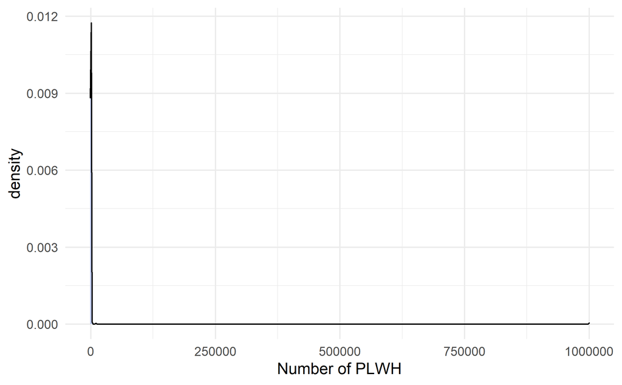

## External Norms (What other people think about what you should do)

### ART (0-18)

| n | Mean | sd | Median | IQR | Min | Max |
| --- | --- | --- | --- | --- | --- | --- |
| 400 | 15.06 | 3.88 | 17 | 5 | 3 | 18 |

Coefficient Alpha

- **total**:

  | raw_alpha | std.alpha | G6(smc) | average_r | S/N | ase | mean | sd | median_r |
  | --- | --- | --- | --- | --- | --- | --- | --- | --- |
  | 0.638 | 0.6174 | 0.6133 | 0.3498 | 1.614 | 0.02966 | 5.021 | 1.294 | 0.2121 |

- **alpha.drop**:

  |  | raw_alpha | std.alpha | G6(smc) | average_r | S/N | alpha se | var.r | med.r |
  | --- | --- | --- | --- | --- | --- | --- | --- | --- |
  | **fu4_peer_norms_q13** | 0.3439 | 0.35 | 0.2121 | 0.2121 | 0.5384 | 0.06307 | NA | 0.2121 |
  | **fu4_peer_norms_q14** | 0.8209 | 0.821 | 0.6964 | 0.6964 | 4.587 | 0.0176 | NA | 0.6964 |
  | **fu4_peer_norms_q15** | 0.2412 | 0.2469 | 0.1408 | 0.1408 | 0.3278 | 0.0726 | NA | 0.1408 |

- **item.stats**:

  |  | n | raw.r | std.r | r.cor | r.drop | mean | sd |
  | --- | --- | --- | --- | --- | --- | --- | --- |
  | **fu4_peer_norms_q13** | 396 | 0.8552 | 0.8136 | 0.7477 | 0.5725 | 4.803 | 1.785 |
  | **fu4_peer_norms_q14** | 390 | 0.5478 | 0.5992 | 0.2251 | 0.1911 | 5.385 | 1.416 |
  | **fu4_peer_norms_q15** | 388 | 0.8697 | 0.8452 | 0.7955 | 0.6352 | 4.943 | 1.742 |

- **response.freq**:

  |  | 0 | 1 | 2 | 3 | 4 | 5 | 6 | miss |
  | --- | --- | --- | --- | --- | --- | --- | --- | --- |
  | **fu4_peer_norms_q13** | 0.05303 | 0.04798 | 0.02778 | 0.06313 | 0.07576 | 0.1869 | 0.5455 | 0.04348 |
  | **fu4_peer_norms_q14** | 0.02564 | 0.01795 | 0.02564 | 0.04103 | 0.04103 | 0.0641 | 0.7846 | 0.05797 |
  | **fu4_peer_norms_q15** | 0.0567 | 0.03093 | 0.02577 | 0.05928 | 0.05155 | 0.1778 | 0.5979 | 0.0628 |

### HIV Care (0-18)

| n | Mean | sd | Median | IQR | Min | Max |
| --- | --- | --- | --- | --- | --- | --- |
| 405 | 14.16 | 4.21 | 16 | 7 | 0 | 18 |

Coefficient Alpha

- **total**:

  | raw_alpha | std.alpha | G6(smc) | average_r | S/N | ase | mean | sd | median_r |
  | --- | --- | --- | --- | --- | --- | --- | --- | --- |
  | 0.5578 | 0.5196 | 0.5635 | 0.265 | 1.082 | 0.03557 | 4.72 | 1.402 | 0.09013 |

- **alpha.drop**:

  |  | raw_alpha | std.alpha | G6(smc) | average_r | S/N | alpha se | var.r | med.r |
  | --- | --- | --- | --- | --- | --- | --- | --- | --- |
  | **fu4_peer_norms_q1** | 0.1615 | 0.1654 | 0.09013 | 0.09013 | 0.1981 | 0.08032 | NA | 0.09013 |
  | **fu4_peer_norms_q2** | 0.821 | 0.8216 | 0.6972 | 0.6972 | 4.605 | 0.01755 | NA | 0.6972 |
  | **fu4_peer_norms_q3** | 0.01464 | 0.01519 | 0.007656 | 0.007656 | 0.01543 | 0.0933 | NA | 0.007656 |

- **item.stats**:

  |  | n | raw.r | std.r | r.cor | r.drop | mean | sd |
  | --- | --- | --- | --- | --- | --- | --- | --- |
  | **fu4_peer_norms_q1** | 398 | 0.8428 | 0.7958 | 0.7424 | 0.5274 | 4.359 | 2.079 |
  | **fu4_peer_norms_q2** | 398 | 0.4318 | 0.5124 | 0.06954 | 0.052 | 5.244 | 1.579 |
  | **fu4_peer_norms_q3** | 394 | 0.8661 | 0.8343 | 0.7963 | 0.6075 | 4.591 | 1.982 |

- **response.freq**:

  |  | 0 | 1 | 2 | 3 | 4 | 5 | 6 | miss |
  | --- | --- | --- | --- | --- | --- | --- | --- | --- |
  | **fu4_peer_norms_q1** | 0.08794 | 0.08543 | 0.03769 | 0.07286 | 0.06281 | 0.191 | 0.4623 | 0.03865 |
  | **fu4_peer_norms_q2** | 0.03266 | 0.04271 | 0.01508 | 0.02764 | 0.0603 | 0.08291 | 0.7387 | 0.03865 |
  | **fu4_peer_norms_q3** | 0.07868 | 0.06853 | 0.02284 | 0.06091 | 0.06091 | 0.198 | 0.5102 | 0.04831 |

## Egocentric/Descriptive Norms (What you think other people are doing)

### ART (0-24)

| n | Mean | sd | Median | IQR | Min | Max |
| --- | --- | --- | --- | --- | --- | --- |
| 364 | 17.82 | 5.19 | 19 | 8 | 0 | 24 |

Coefficient Alpha

- **total**:

  | raw_alpha | std.alpha | G6(smc) | average_r | S/N | ase | mean | sd | median_r |
  | --- | --- | --- | --- | --- | --- | --- | --- | --- |
  | 0.7366 | 0.7373 | 0.7304 | 0.4124 | 2.807 | 0.0217 | 4.455 | 1.297 | 0.3698 |

- **alpha.drop**:

  |  | raw_alpha | std.alpha | G6(smc) | average_r | S/N | alpha se | var.r | med.r |
  | --- | --- | --- | --- | --- | --- | --- | --- | --- |
  | **fu4_peer_norms_q16** | 0.6898 | 0.693 | 0.6278 | 0.4294 | 2.258 | 0.02686 | 0.02143 | 0.4179 |
  | **fu4_peer_norms_q17** | 0.6545 | 0.6521 | 0.6031 | 0.3845 | 1.874 | 0.02971 | 0.04375 | 0.2891 |
  | **fu4_peer_norms_q18** | 0.717 | 0.7144 | 0.6539 | 0.4546 | 2.501 | 0.02411 | 0.02393 | 0.4179 |
  | **fu4_peer_norms_q19** | 0.6437 | 0.6487 | 0.5879 | 0.381 | 1.846 | 0.03097 | 0.03174 | 0.3216 |

- **item.stats**:

  |  | n | raw.r | std.r | r.cor | r.drop | mean | sd |
  | --- | --- | --- | --- | --- | --- | --- | --- |
  | **fu4_peer_norms_q16** | 350 | 0.7724 | 0.7308 | 0.6186 | 0.507 | 4.331 | 1.708 |
  | **fu4_peer_norms_q17** | 323 | 0.7691 | 0.7758 | 0.676 | 0.5701 | 4.663 | 1.576 |
  | **fu4_peer_norms_q18** | 315 | 0.7022 | 0.7055 | 0.5679 | 0.4564 | 4.651 | 1.639 |
  | **fu4_peer_norms_q19** | 335 | 0.7982 | 0.7794 | 0.694 | 0.5842 | 4.272 | 1.685 |

- **response.freq**:

  |  | 0 | 1 | 2 | 3 | 4 | 5 | 6 | miss |
  | --- | --- | --- | --- | --- | --- | --- | --- | --- |
  | **fu4_peer_norms_q16** | 0.03429 | 0.05429 | 0.06286 | 0.1457 | 0.14 | 0.2229 | 0.34 | 0.1546 |
  | **fu4_peer_norms_q17** | 0.01858 | 0.04644 | 0.04954 | 0.1146 | 0.0805 | 0.291 | 0.3994 | 0.2198 |
  | **fu4_peer_norms_q18** | 0.03175 | 0.03492 | 0.04762 | 0.1206 | 0.1016 | 0.2286 | 0.4349 | 0.2391 |
  | **fu4_peer_norms_q19** | 0.03582 | 0.06269 | 0.05075 | 0.1373 | 0.1642 | 0.2567 | 0.2925 | 0.1908 |

### HIV Care (0-24)

| n | Mean | sd | Median | IQR | Min | Max |
| --- | --- | --- | --- | --- | --- | --- |
| 363 | 17.49 | 4.98 | 18 | 9 | 2 | 24 |

Coefficient Alpha

- **total**:

  | raw_alpha | std.alpha | G6(smc) | average_r | S/N | ase | mean | sd | median_r |
  | --- | --- | --- | --- | --- | --- | --- | --- | --- |
  | 0.6637 | 0.6636 | 0.6783 | 0.3303 | 1.972 | 0.02789 | 4.373 | 1.245 | 0.2405 |

- **alpha.drop**:

  |  | raw_alpha | std.alpha | G6(smc) | average_r | S/N | alpha se | var.r | med.r |
  | --- | --- | --- | --- | --- | --- | --- | --- | --- |
  | **fu4_peer_norms_q5** | 0.5745 | 0.5778 | 0.5108 | 0.3133 | 1.369 | 0.0367 | 0.02898 | 0.2691 |
  | **fu4_peer_norms_q6** | 0.6023 | 0.5997 | 0.5832 | 0.3331 | 1.498 | 0.03445 | 0.08096 | 0.1695 |
  | **fu4_peer_norms_q7** | 0.6542 | 0.6486 | 0.6157 | 0.3809 | 1.846 | 0.0296 | 0.05994 | 0.2691 |
  | **fu4_peer_norms_q8** | 0.5481 | 0.5551 | 0.4905 | 0.2937 | 1.248 | 0.03914 | 0.03278 | 0.2119 |

- **item.stats**:

  |  | n | raw.r | std.r | r.cor | r.drop | mean | sd |
  | --- | --- | --- | --- | --- | --- | --- | --- |
  | **fu4_peer_norms_q5** | 353 | 0.7473 | 0.7235 | 0.638 | 0.4758 | 4.261 | 1.795 |
  | **fu4_peer_norms_q6** | 323 | 0.6874 | 0.7025 | 0.5459 | 0.4362 | 4.585 | 1.631 |
  | **fu4_peer_norms_q7** | 321 | 0.6589 | 0.6516 | 0.4708 | 0.3563 | 4.486 | 1.716 |
  | **fu4_peer_norms_q8** | 340 | 0.7709 | 0.7443 | 0.6693 | 0.5142 | 4.194 | 1.722 |

- **response.freq**:

  |  | 0 | 1 | 2 | 3 | 4 | 5 | 6 | miss |
  | --- | --- | --- | --- | --- | --- | --- | --- | --- |
  | **fu4_peer_norms_q5** | 0.04249 | 0.06232 | 0.07082 | 0.1445 | 0.1303 | 0.1955 | 0.3541 | 0.1473 |
  | **fu4_peer_norms_q6** | 0.01858 | 0.05882 | 0.04644 | 0.1269 | 0.09288 | 0.257 | 0.3994 | 0.2198 |
  | **fu4_peer_norms_q7** | 0.0405 | 0.04673 | 0.04673 | 0.1371 | 0.09034 | 0.2586 | 0.3801 | 0.2246 |
  | **fu4_peer_norms_q8** | 0.03824 | 0.06765 | 0.04706 | 0.1794 | 0.1353 | 0.2412 | 0.2912 | 0.1787 |

## Internal Norms (How you feel about things others may do)

### ART (0-12)

| n | Mean | sd | Median | IQR | Min | Max |
| --- | --- | --- | --- | --- | --- | --- |
| 407 | 10.26 | 2.31 | 11 | 3 | 0 | 12 |

Coefficient Alpha

- **total**:

  | raw_alpha | std.alpha | G6(smc) | average_r | S/N | ase | mean | sd | median_r |
  | --- | --- | --- | --- | --- | --- | --- | --- | --- |
  | 0.6674 | 0.6892 | 0.6249 | 0.4251 | 2.218 | 0.02902 | 3.419 | 0.7698 | 0.3586 |

- **alpha.drop**:

  |  | raw_alpha | std.alpha | G6(smc) | average_r | S/N | alpha se | var.r | med.r |
  | --- | --- | --- | --- | --- | --- | --- | --- | --- |
  | **fu4_peer_norms_q21** | 0.4655 | 0.4744 | 0.3109 | 0.3109 | 0.9025 | 0.05112 | NA | 0.3109 |
  | **fu4_peer_norms_q22** | 0.5132 | 0.5279 | 0.3586 | 0.3586 | 1.118 | 0.04581 | NA | 0.3586 |
  | **fu4_peer_norms_q23** | 0.7537 | 0.7544 | 0.6056 | 0.6056 | 3.071 | 0.02416 | NA | 0.6056 |

- **item.stats**:

  |  | n | raw.r | std.r | r.cor | r.drop | mean | sd |
  | --- | --- | --- | --- | --- | --- | --- | --- |
  | **fu4_peer_norms_q21** | 399 | 0.8184 | 0.8337 | 0.7319 | 0.5767 | 3.521 | 0.8471 |
  | **fu4_peer_norms_q22** | 401 | 0.8001 | 0.8135 | 0.6945 | 0.5289 | 3.399 | 0.8947 |
  | **fu4_peer_norms_q23** | 388 | 0.7672 | 0.7087 | 0.436 | 0.3729 | 3.389 | 1.119 |

- **response.freq**:

  |  | 0 | 1 | 2 | 3 | 4 | miss |
  | --- | --- | --- | --- | --- | --- | --- |
  | **fu4_peer_norms_q21** | 0.01754 | 0.01504 | 0.08271 | 0.198 | 0.6867 | 0.03623 |
  | **fu4_peer_norms_q22** | 0.01995 | 0.02494 | 0.08479 | 0.2768 | 0.5935 | 0.0314 |
  | **fu4_peer_norms_q23** | 0.05412 | 0.04124 | 0.0567 | 0.1572 | 0.6907 | 0.0628 |

### HIV Care (0-12)

| n | Mean | sd | Median | IQR | Min | Max |
| --- | --- | --- | --- | --- | --- | --- |
| 408 | 10.3 | 2.22 | 11 | 3 | 0 | 12 |

Coefficient Alpha

- **total**:

  | raw_alpha | std.alpha | G6(smc) | average_r | S/N | ase | mean | sd | median_r |
  | --- | --- | --- | --- | --- | --- | --- | --- | --- |
  | 0.5807 | 0.6142 | 0.5606 | 0.3467 | 1.592 | 0.03689 | 3.434 | 0.7415 | 0.2684 |

- **alpha.drop**:

  |  | raw_alpha | std.alpha | G6(smc) | average_r | S/N | alpha se | var.r | med.r |
  | --- | --- | --- | --- | --- | --- | --- | --- | --- |
  | **fu4_peer_norms_q10** | 0.3199 | 0.3256 | 0.1945 | 0.1945 | 0.4828 | 0.0654 | NA | 0.1945 |
  | **fu4_peer_norms_q11** | 0.4054 | 0.4232 | 0.2684 | 0.2684 | 0.7338 | 0.05514 | NA | 0.2684 |
  | **fu4_peer_norms_q12** | 0.7282 | 0.7319 | 0.5771 | 0.5771 | 2.73 | 0.0264 | NA | 0.5771 |

- **item.stats**:

  |  | n | raw.r | std.r | r.cor | r.drop | mean | sd |
  | --- | --- | --- | --- | --- | --- | --- | --- |
  | **fu4_peer_norms_q10** | 403 | 0.7897 | 0.8188 | 0.7135 | 0.5246 | 3.586 | 0.8253 |
  | **fu4_peer_norms_q11** | 396 | 0.7607 | 0.786 | 0.6556 | 0.4414 | 3.386 | 0.9358 |
  | **fu4_peer_norms_q12** | 386 | 0.7234 | 0.649 | 0.3184 | 0.2579 | 3.35 | 1.151 |

- **response.freq**:

  |  | 0 | 1 | 2 | 3 | 4 | miss |
  | --- | --- | --- | --- | --- | --- | --- |
  | **fu4_peer_norms_q10** | 0.01985 | 0.01737 | 0.04715 | 0.1886 | 0.727 | 0.02657 |
  | **fu4_peer_norms_q11** | 0.02273 | 0.0303 | 0.09091 | 0.25 | 0.6061 | 0.04348 |
  | **fu4_peer_norms_q12** | 0.0544 | 0.0544 | 0.05699 | 0.1554 | 0.6788 | 0.06763 |

# HIV Social Stigma

- Rintamaki, L.S., Davis, T.C., Skripkauskas, S., Bennett, C.L. & Wolf, M.S. (2006). Social stigma concerns and HIV medication adherence. *AIDS Patient Care and STDs*, 20(5): 359-368.
- Sayles, Jennifer N., et al. Development and psychometric assessment of a multidimensional measure of internalized HIV stigma in a sample of HIV-positive adults. *AIDS and Behavior* 12.5 (2008): 748-758.

## Medication Stigma (3-9)

| n | Mean | sd | Median | IQR | Min | Max |
| --- | --- | --- | --- | --- | --- | --- |
| 397 | 5.1 | 2.2 | 5 | 4 | 3 | 9 |

Coefficient Alpha

- **total**:

  | raw_alpha | std.alpha | G6(smc) | average_r | S/N | ase | mean | sd | median_r |
  | --- | --- | --- | --- | --- | --- | --- | --- | --- |
  | 0.6569 | 0.6704 | 0.6046 | 0.404 | 2.034 | 0.02923 | 1.699 | 0.7329 | 0.391 |

- **alpha.drop**:

  |  | raw_alpha | std.alpha | G6(smc) | average_r | S/N | alpha se | var.r | med.r |
  | --- | --- | --- | --- | --- | --- | --- | --- | --- |
  | **fu4_hiv_soc_stigma_q4** | 0.5604 | 0.5622 | 0.391 | 0.391 | 1.284 | 0.04298 | NA | 0.391 |
  | **fu4_hiv_soc_stigma_q5** | 0.3957 | 0.4102 | 0.258 | 0.258 | 0.6955 | 0.05661 | NA | 0.258 |
  | **fu4_hiv_soc_stigma_q6** | 0.7106 | 0.7204 | 0.563 | 0.563 | 2.577 | 0.02758 | NA | 0.563 |

- **item.stats**:

  |  | n | raw.r | std.r | r.cor | r.drop | mean | sd |
  | --- | --- | --- | --- | --- | --- | --- | --- |
  | **fu4_hiv_soc_stigma_q4** | 364 | 0.7477 | 0.7819 | 0.6293 | 0.4833 | 1.324 | 0.7381 |
  | **fu4_hiv_soc_stigma_q5** | 363 | 0.8453 | 0.839 | 0.7376 | 0.5813 | 1.579 | 0.9081 |
  | **fu4_hiv_soc_stigma_q6** | 372 | 0.7597 | 0.7081 | 0.444 | 0.3743 | 2.07 | 0.9989 |

- **response.freq**:

  |  | 1 | 3 | miss |
  | --- | --- | --- | --- |
  | **fu4_hiv_soc_stigma_q4** | 0.8379 | 0.1621 | 0.1208 |
  | **fu4_hiv_soc_stigma_q5** | 0.7107 | 0.2893 | 0.1232 |
  | **fu4_hiv_soc_stigma_q6** | 0.4651 | 0.5349 | 0.1014 |

## Care Stigma (3-9)

| n | Mean | sd | Median | IQR | Min | Max |
| --- | --- | --- | --- | --- | --- | --- |
| 397 | 4.85 | 2.1 | 5 | 3 | 3 | 9 |

## Disclosure Concern (0-20)

| n | Mean | sd | Median | IQR | Min | Max |
| --- | --- | --- | --- | --- | --- | --- |
| 393 | 4.01 | 5.58 | 1 | 6.25 | 0 | 20 |

Coefficient Alpha

- **total**:

  | raw_alpha | std.alpha | G6(smc) | average_r | S/N | ase | mean | sd | median_r |
  | --- | --- | --- | --- | --- | --- | --- | --- | --- |
  | 0.9116 | 0.9122 | 0.8946 | 0.6752 | 10.39 | 0.006856 | 0.8027 | 1.116 | 0.6657 |

- **alpha.drop**:

  |  | raw_alpha | std.alpha | G6(smc) | average_r | S/N | alpha se | var.r | med.r |
  | --- | --- | --- | --- | --- | --- | --- | --- | --- |
  | **fu4_hiv_soc_stigma_q10** | 0.8877 | 0.8889 | 0.8595 | 0.6667 | 8 | 0.008999 | 0.001199 | 0.6554 |
  | **fu4_hiv_soc_stigma_q11** | 0.892 | 0.8926 | 0.8633 | 0.6751 | 8.311 | 0.008648 | 0.00121 | 0.6657 |
  | **fu4_hiv_soc_stigma_q12** | 0.885 | 0.8854 | 0.8547 | 0.6589 | 7.725 | 0.0092 | 0.0009191 | 0.6485 |
  | **fu4_hiv_soc_stigma_q8** | 0.8991 | 0.9002 | 0.8735 | 0.6928 | 9.019 | 0.008122 | 0.00118 | 0.7089 |
  | **fu4_hiv_soc_stigma_q9** | 0.8953 | 0.8958 | 0.867 | 0.6824 | 8.595 | 0.008353 | 0.001132 | 0.6817 |

- **item.stats**:

  |  | n | raw.r | std.r | r.cor | r.drop | mean | sd |
  | --- | --- | --- | --- | --- | --- | --- | --- |
  | **fu4_hiv_soc_stigma_q10** | 364 | 0.8919 | 0.8722 | 0.8329 | 0.7947 | 0.7115 | 1.258 |
  | **fu4_hiv_soc_stigma_q11** | 345 | 0.8806 | 0.8604 | 0.8146 | 0.776 | 0.7739 | 1.31 |
  | **fu4_hiv_soc_stigma_q12** | 350 | 0.8923 | 0.883 | 0.8505 | 0.8116 | 0.6343 | 1.177 |
  | **fu4_hiv_soc_stigma_q8** | 353 | 0.8594 | 0.8358 | 0.7724 | 0.7396 | 0.6969 | 1.185 |
  | **fu4_hiv_soc_stigma_q9** | 354 | 0.8547 | 0.8502 | 0.7981 | 0.7598 | 0.839 | 1.288 |

- **response.freq**:

  |  | 0 | 1 | 2 | 4 | miss |
  | --- | --- | --- | --- | --- | --- |
  | **fu4_hiv_soc_stigma_q10** | 0.6868 | 0.1071 | 0.1099 | 0.09615 | 0.1208 |
  | **fu4_hiv_soc_stigma_q11** | 0.6725 | 0.09565 | 0.1246 | 0.1072 | 0.1667 |
  | **fu4_hiv_soc_stigma_q12** | 0.7086 | 0.1029 | 0.1114 | 0.07714 | 0.1546 |
  | **fu4_hiv_soc_stigma_q8** | 0.6686 | 0.119 | 0.136 | 0.07649 | 0.1473 |
  | **fu4_hiv_soc_stigma_q9** | 0.6158 | 0.1328 | 0.1497 | 0.1017 | 0.1449 |

# HIV Medication and Care Self-Efficacy

- Erlen, J.A., Cha, E.S., Kim, K.H., Caruthers, D. & Sereika, S. (2010). The HIV medication taking self-efficacy scale: Psychometric evaluation. *Journal of Advanced Nursing*, 66(11): 2560-2572.

## Self-Efficacy Beliefs (1-10)

| n | Mean | sd | Median | IQR | Min | Max |
| --- | --- | --- | --- | --- | --- | --- |
| 413 | 7.67 | 2.36 | 8.54 | 3.85 | 1 | 10 |

Coefficient Alpha

- **total**:

  | raw_alpha | std.alpha | G6(smc) | average_r | S/N | ase | mean | sd | median_r |
  | --- | --- | --- | --- | --- | --- | --- | --- | --- |
  | 0.967 | 0.9677 | 0.9759 | 0.6976 | 29.99 | 0.002334 | 7.672 | 2.363 | 0.7335 |

- **alpha.drop**:

  |  | raw_alpha | std.alpha | G6(smc) | average_r | S/N | alpha se | var.r | med.r |
  | --- | --- | --- | --- | --- | --- | --- | --- | --- |
  | **fu4_hiv_med_care_q1** | 0.9696 | 0.971 | 0.9787 | 0.7364 | 33.53 | 0.002235 | 0.008076 | 0.7455 |
  | **fu4_hiv_med_care_q10** | 0.9643 | 0.9648 | 0.9731 | 0.6956 | 27.43 | 0.002524 | 0.01693 | 0.7304 |
  | **fu4_hiv_med_care_q11** | 0.9648 | 0.9658 | 0.9741 | 0.7016 | 28.21 | 0.002497 | 0.0174 | 0.7441 |
  | **fu4_hiv_med_care_q12** | 0.9671 | 0.9675 | 0.9747 | 0.713 | 29.81 | 0.002321 | 0.01526 | 0.7446 |
  | **fu4_hiv_med_care_q13** | 0.9656 | 0.9662 | 0.9729 | 0.7045 | 28.61 | 0.002432 | 0.01655 | 0.7433 |
  | **fu4_hiv_med_care_q2** | 0.9639 | 0.9646 | 0.9734 | 0.694 | 27.22 | 0.002549 | 0.01725 | 0.7271 |
  | **fu4_hiv_med_care_q3** | 0.964 | 0.9643 | 0.9714 | 0.6926 | 27.04 | 0.002536 | 0.01619 | 0.7304 |
  | **fu4_hiv_med_care_q4** | 0.9635 | 0.9641 | 0.9727 | 0.6909 | 26.83 | 0.002576 | 0.0167 | 0.7271 |
  | **fu4_hiv_med_care_q5** | 0.9621 | 0.963 | 0.9715 | 0.6846 | 26.05 | 0.002699 | 0.01546 | 0.7167 |
  | **fu4_hiv_med_care_q6** | 0.9633 | 0.9642 | 0.9726 | 0.6917 | 26.92 | 0.002627 | 0.0163 | 0.7304 |
  | **fu4_hiv_med_care_q7** | 0.9625 | 0.9634 | 0.9723 | 0.6869 | 26.32 | 0.002668 | 0.01599 | 0.7271 |
  | **fu4_hiv_med_care_q8** | 0.9626 | 0.9636 | 0.9726 | 0.688 | 26.46 | 0.002669 | 0.01628 | 0.7167 |
  | **fu4_hiv_med_care_q9** | 0.963 | 0.9637 | 0.9731 | 0.6887 | 26.55 | 0.00262 | 0.01695 | 0.7262 |

- **item.stats**:

  |  | n | raw.r | std.r | r.cor | r.drop | mean | sd |
  | --- | --- | --- | --- | --- | --- | --- | --- |
  | **fu4_hiv_med_care_q1** | 413 | 0.5995 | 0.6166 | 0.5667 | 0.55 | 8.322 | 2.224 |
  | **fu4_hiv_med_care_q10** | 413 | 0.8515 | 0.8607 | 0.8528 | 0.827 | 8.249 | 2.466 |
  | **fu4_hiv_med_care_q11** | 413 | 0.8322 | 0.8251 | 0.809 | 0.7991 | 7.39 | 2.926 |
  | **fu4_hiv_med_care_q12** | 413 | 0.7705 | 0.7569 | 0.7354 | 0.7226 | 6.625 | 3.2 |
  | **fu4_hiv_med_care_q13** | 413 | 0.8212 | 0.8076 | 0.7959 | 0.7821 | 6.874 | 3.221 |
  | **fu4_hiv_med_care_q2** | 413 | 0.8636 | 0.8703 | 0.8604 | 0.8388 | 7.959 | 2.674 |
  | **fu4_hiv_med_care_q3** | 413 | 0.8676 | 0.8789 | 0.8789 | 0.8457 | 8.269 | 2.435 |
  | **fu4_hiv_med_care_q4** | 413 | 0.8815 | 0.8888 | 0.8843 | 0.861 | 8.099 | 2.522 |
  | **fu4_hiv_med_care_q5** | 413 | 0.9295 | 0.9265 | 0.929 | 0.9152 | 7.639 | 2.82 |
  | **fu4_hiv_med_care_q6** | 413 | 0.8908 | 0.8843 | 0.8809 | 0.8664 | 7.189 | 3.152 |
  | **fu4_hiv_med_care_q7** | 413 | 0.9147 | 0.913 | 0.9118 | 0.8976 | 7.751 | 2.82 |
  | **fu4_hiv_med_care_q8** | 413 | 0.9104 | 0.9065 | 0.903 | 0.8916 | 7.472 | 2.942 |
  | **fu4_hiv_med_care_q9** | 413 | 0.8981 | 0.9022 | 0.8955 | 0.8789 | 7.898 | 2.687 |

- **response.freq**:

## Outcome Expectancies (1-10)

| n | Mean | sd | Median | IQR | Min | Max |
| --- | --- | --- | --- | --- | --- | --- |
| 413 | 8.72 | 1.99 | 9.8 | 1.8 | 1 | 10 |

Coefficient Alpha

- **total**:

  | raw_alpha | std.alpha | G6(smc) | average_r | S/N | ase | mean | sd | median_r |
  | --- | --- | --- | --- | --- | --- | --- | --- | --- |
  | 0.9782 | 0.9786 | 0.9841 | 0.7534 | 45.83 | 0.00159 | 8.719 | 1.986 | 0.7472 |

- **alpha.drop**:

  |  | raw_alpha | std.alpha | G6(smc) | average_r | S/N | alpha se | var.r | med.r |
  | --- | --- | --- | --- | --- | --- | --- | --- | --- |
  | **fu4_hiv_med_care_q14** | 0.9769 | 0.9774 | 0.9827 | 0.7553 | 43.21 | 0.001691 | 0.005243 | 0.7472 |
  | **fu4_hiv_med_care_q15** | 0.9761 | 0.9766 | 0.9819 | 0.7491 | 41.8 | 0.001743 | 0.005199 | 0.7462 |
  | **fu4_hiv_med_care_q16** | 0.9758 | 0.9764 | 0.9819 | 0.7468 | 41.3 | 0.001767 | 0.005065 | 0.7378 |
  | **fu4_hiv_med_care_q17** | 0.9761 | 0.9766 | 0.9825 | 0.7491 | 41.8 | 0.001751 | 0.005339 | 0.7391 |
  | **fu4_hiv_med_care_q18** | 0.9759 | 0.9764 | 0.9822 | 0.7468 | 41.28 | 0.001762 | 0.004998 | 0.7391 |
  | **fu4_hiv_med_care_q19** | 0.9759 | 0.9765 | 0.9823 | 0.7476 | 41.47 | 0.001758 | 0.005189 | 0.7384 |
  | **fu4_hiv_med_care_q20** | 0.9777 | 0.978 | 0.9829 | 0.7606 | 44.49 | 0.001628 | 0.005417 | 0.7598 |
  | **fu4_hiv_med_care_q21** | 0.9781 | 0.9787 | 0.9827 | 0.7665 | 45.97 | 0.001591 | 0.004252 | 0.7583 |
  | **fu4_hiv_med_care_q22** | 0.9775 | 0.9781 | 0.9829 | 0.761 | 44.59 | 0.001641 | 0.005438 | 0.7598 |
  | **fu4_hiv_med_care_q23** | 0.9775 | 0.9778 | 0.9837 | 0.7591 | 44.12 | 0.001649 | 0.005713 | 0.766 |
  | **fu4_hiv_med_care_q24** | 0.9767 | 0.9771 | 0.9826 | 0.7533 | 42.75 | 0.001707 | 0.005528 | 0.7391 |
  | **fu4_hiv_med_care_q25** | 0.9761 | 0.9766 | 0.9822 | 0.7488 | 41.72 | 0.001743 | 0.005015 | 0.7391 |
  | **fu4_hiv_med_care_q26** | 0.9768 | 0.9773 | 0.9826 | 0.7545 | 43.02 | 0.001696 | 0.005295 | 0.7462 |
  | **fu4_hiv_med_care_q27** | 0.9764 | 0.9769 | 0.9822 | 0.7514 | 42.32 | 0.001725 | 0.005449 | 0.7462 |
  | **fu4_hiv_med_care_q28** | 0.9764 | 0.9769 | 0.9827 | 0.7512 | 42.27 | 0.001726 | 0.005292 | 0.7447 |

- **item.stats**:

  |  | n | raw.r | std.r | r.cor | r.drop | mean | sd |
  | --- | --- | --- | --- | --- | --- | --- | --- |
  | **fu4_hiv_med_care_q14** | 413 | 0.8628 | 0.8644 | 0.8565 | 0.8421 | 8.792 | 2.187 |
  | **fu4_hiv_med_care_q15** | 413 | 0.9061 | 0.9073 | 0.9053 | 0.8912 | 8.789 | 2.223 |
  | **fu4_hiv_med_care_q16** | 413 | 0.9229 | 0.923 | 0.9215 | 0.9104 | 8.746 | 2.252 |
  | **fu4_hiv_med_care_q17** | 413 | 0.9075 | 0.9072 | 0.9022 | 0.8919 | 8.584 | 2.353 |
  | **fu4_hiv_med_care_q18** | 413 | 0.9219 | 0.9234 | 0.921 | 0.9097 | 8.818 | 2.191 |
  | **fu4_hiv_med_care_q19** | 413 | 0.9168 | 0.9176 | 0.9139 | 0.9035 | 8.671 | 2.232 |
  | **fu4_hiv_med_care_q20** | 413 | 0.831 | 0.8275 | 0.8154 | 0.8018 | 8.521 | 2.522 |
  | **fu4_hiv_med_care_q21** | 413 | 0.7897 | 0.7866 | 0.7742 | 0.758 | 8.826 | 2.283 |
  | **fu4_hiv_med_care_q22** | 413 | 0.8268 | 0.8247 | 0.8126 | 0.8001 | 8.765 | 2.279 |
  | **fu4_hiv_med_care_q23** | 413 | 0.8411 | 0.8379 | 0.8211 | 0.8131 | 8.448 | 2.552 |
  | **fu4_hiv_med_care_q24** | 413 | 0.8756 | 0.878 | 0.8706 | 0.858 | 8.86 | 2.047 |
  | **fu4_hiv_med_care_q25** | 413 | 0.9075 | 0.9096 | 0.9065 | 0.8931 | 8.809 | 2.188 |
  | **fu4_hiv_med_care_q26** | 413 | 0.8682 | 0.87 | 0.863 | 0.8481 | 8.777 | 2.205 |
  | **fu4_hiv_med_care_q27** | 413 | 0.8909 | 0.8911 | 0.8862 | 0.8735 | 8.685 | 2.259 |
  | **fu4_hiv_med_care_q28** | 413 | 0.8918 | 0.8928 | 0.8861 | 0.8749 | 8.69 | 2.22 |

- **response.freq**:

# HIV Adherence Self-Efficacy (0-120)

- Johnson, M. O., Neilands, T. B., Dilworth, S. E., Morin, S. F., Remien, R. H., & Chesney, M. A. (2007). The role of self-efficacy in HIV treatment adherence: validation of the HIV Treatment Adherence Self-Efficacy Scale (HIV-ASES). *Journal of behavioral medicine*, 30(5), 359-370.

| n | Mean | sd | Median | IQR | Min | Max |
| --- | --- | --- | --- | --- | --- | --- |
| 409 | 90.6 | 27.99 | 96 | 46 | 0 | 120 |

Coefficient Alpha

- **total**:

  | raw_alpha | std.alpha | G6(smc) | average_r | S/N | ase | mean | sd | median_r |
  | --- | --- | --- | --- | --- | --- | --- | --- | --- |
  | 0.9575 | 0.9583 | 0.9631 | 0.6569 | 22.97 | 0.003116 | 7.55 | 2.333 | 0.6445 |

- **alpha.drop**:

  |  | raw_alpha | std.alpha | G6(smc) | average_r | S/N | alpha se | var.r | med.r |
  | --- | --- | --- | --- | --- | --- | --- | --- | --- |
  | **fu4_hiv_ases_q10** | 0.9547 | 0.9557 | 0.9587 | 0.6623 | 21.57 | 0.003326 | 0.005278 | 0.6562 |
  | **fu4_hiv_ases_q11** | 0.9519 | 0.9529 | 0.9568 | 0.648 | 20.25 | 0.003537 | 0.005233 | 0.6393 |
  | **fu4_hiv_ases_q12** | 0.9523 | 0.9533 | 0.9577 | 0.6497 | 20.4 | 0.003506 | 0.005359 | 0.6388 |
  | **fu4_hiv_ases_q13** | 0.9539 | 0.9549 | 0.9594 | 0.6582 | 21.18 | 0.003391 | 0.005823 | 0.6528 |
  | **fu4_hiv_ases_q14** | 0.9567 | 0.9572 | 0.9612 | 0.6704 | 22.37 | 0.003186 | 0.00504 | 0.6665 |
  | **fu4_hiv_ases_q2** | 0.9562 | 0.9571 | 0.9615 | 0.6696 | 22.3 | 0.003222 | 0.005403 | 0.6665 |
  | **fu4_hiv_ases_q3** | 0.9546 | 0.9554 | 0.9594 | 0.6609 | 21.44 | 0.00335 | 0.005612 | 0.6414 |
  | **fu4_hiv_ases_q4** | 0.9539 | 0.9548 | 0.9592 | 0.6575 | 21.12 | 0.00339 | 0.005643 | 0.6414 |
  | **fu4_hiv_ases_q5** | 0.9524 | 0.9532 | 0.9579 | 0.6495 | 20.38 | 0.003499 | 0.00548 | 0.6393 |
  | **fu4_hiv_ases_q6** | 0.953 | 0.954 | 0.9581 | 0.6533 | 20.73 | 0.003456 | 0.005684 | 0.6397 |
  | **fu4_hiv_ases_q7** | 0.9537 | 0.9547 | 0.9594 | 0.6569 | 21.06 | 0.003407 | 0.005831 | 0.6475 |
  | **fu4_hiv_ases_q9** | 0.9518 | 0.9526 | 0.9576 | 0.6463 | 20.1 | 0.003546 | 0.005226 | 0.6388 |

- **item.stats**:

  |  | n | raw.r | std.r | r.cor | r.drop | mean | sd |
  | --- | --- | --- | --- | --- | --- | --- | --- |
  | **fu4_hiv_ases_q10** | 395 | 0.7999 | 0.7982 | 0.7832 | 0.7584 | 7.478 | 2.955 |
  | **fu4_hiv_ases_q11** | 399 | 0.8746 | 0.8773 | 0.8735 | 0.8518 | 7.431 | 2.822 |
  | **fu4_hiv_ases_q12** | 402 | 0.8652 | 0.8678 | 0.8605 | 0.8385 | 7.617 | 2.782 |
  | **fu4_hiv_ases_q13** | 395 | 0.8209 | 0.8206 | 0.8026 | 0.7827 | 7.808 | 2.787 |
  | **fu4_hiv_ases_q14** | 394 | 0.759 | 0.7532 | 0.7232 | 0.7063 | 6.977 | 3.171 |
  | **fu4_hiv_ases_q2** | 393 | 0.7587 | 0.7574 | 0.7259 | 0.7091 | 7.369 | 2.956 |
  | **fu4_hiv_ases_q3** | 403 | 0.8023 | 0.8058 | 0.786 | 0.7639 | 8.072 | 2.539 |
  | **fu4_hiv_ases_q4** | 399 | 0.8174 | 0.8243 | 0.8081 | 0.7848 | 7.619 | 2.835 |
  | **fu4_hiv_ases_q5** | 401 | 0.8678 | 0.8688 | 0.8599 | 0.8388 | 7.696 | 2.69 |
  | **fu4_hiv_ases_q6** | 401 | 0.8532 | 0.8477 | 0.8365 | 0.8141 | 7.369 | 2.867 |
  | **fu4_hiv_ases_q7** | 403 | 0.8321 | 0.8278 | 0.811 | 0.7913 | 7.516 | 2.784 |
  | **fu4_hiv_ases_q9** | 404 | 0.8838 | 0.8864 | 0.8796 | 0.8607 | 7.733 | 2.665 |

- **response.freq**:

# Beliefs about Medicine (8-40)

- Horne, R., Buick, D., Fisher, M., Leake, H., Cooper, V., & Weinman, J. (2004). Doubts about necessity and concerns about adverse effects: identifying the types of beliefs that are associated with non-adherence to HAART. *International Journal of STD & AIDS*, 15(1), 38-44.
- Horne, R., Cooper, V., Gellaitry, G., Date, H. L., & Fisher, M. (2007). Patients’ perceptions of highly active antiretroviral therapy in relation to treatment uptake and adherence: the utility of the necessity-concerns framework. *JAIDS Journal of Acquired Immune Deficiency Syndromes*, 45(3), 334-341.

| n | Mean | sd | Median | IQR | Min | Max |
| --- | --- | --- | --- | --- | --- | --- |
| 409 | 30.52 | 6.33 | 32 | 7 | 8 | 40 |

Coefficient Alpha

- **total**:

  | raw_alpha | std.alpha | G6(smc) | average_r | S/N | ase | mean | sd | median_r |
  | --- | --- | --- | --- | --- | --- | --- | --- | --- |
  | 0.8476 | 0.8615 | 0.8759 | 0.4375 | 6.221 | 0.01105 | 3.815 | 0.7918 | 0.561 |

- **alpha.drop**:

  |  | raw_alpha | std.alpha | G6(smc) | average_r | S/N | alpha se | var.r | med.r |
  | --- | --- | --- | --- | --- | --- | --- | --- | --- |
  | **fu4_bmq_q1** | 0.8239 | 0.842 | 0.8613 | 0.4322 | 5.329 | 0.01306 | 0.09068 | 0.584 |
  | **fu4_bmq_q2** | 0.8138 | 0.8338 | 0.8499 | 0.4175 | 5.018 | 0.01394 | 0.08589 | 0.5577 |
  | **fu4_bmq_q3** | 0.8148 | 0.8339 | 0.8489 | 0.4177 | 5.021 | 0.01375 | 0.08256 | 0.5421 |
  | **fu4_bmq_q4** | 0.805 | 0.823 | 0.8399 | 0.3991 | 4.649 | 0.01438 | 0.08031 | 0.5378 |
  | **fu4_bmq_q5** | 0.8207 | 0.8364 | 0.8531 | 0.4221 | 5.113 | 0.0132 | 0.08728 | 0.567 |
  | **fu4_bmq_q7** | 0.9068 | 0.9101 | 0.904 | 0.5912 | 10.13 | 0.006949 | 0.004314 | 0.584 |
  | **fu4_bmq_q8** | 0.8136 | 0.8286 | 0.8423 | 0.4086 | 4.836 | 0.01371 | 0.07992 | 0.5378 |
  | **fu4_bmq_q9** | 0.815 | 0.8302 | 0.8463 | 0.4113 | 4.89 | 0.01361 | 0.08304 | 0.5421 |

- **item.stats**:

  |  | n | raw.r | std.r | r.cor | r.drop | mean | sd |
  | --- | --- | --- | --- | --- | --- | --- | --- |
  | **fu4_bmq_q1** | 394 | 0.7629 | 0.7319 | 0.6735 | 0.6277 | 3.919 | 1.154 |
  | **fu4_bmq_q2** | 393 | 0.7891 | 0.786 | 0.7559 | 0.6995 | 3.611 | 1.261 |
  | **fu4_bmq_q3** | 387 | 0.7837 | 0.7855 | 0.7586 | 0.6971 | 3.858 | 1.139 |
  | **fu4_bmq_q4** | 386 | 0.8472 | 0.8539 | 0.8472 | 0.7876 | 4.018 | 1.048 |
  | **fu4_bmq_q5** | 385 | 0.7715 | 0.7692 | 0.7326 | 0.6712 | 4.239 | 0.9629 |
  | **fu4_bmq_q7** | 381 | 0.1872 | 0.1461 | -0.02839 | -0.02966 | 3.034 | 1.261 |
  | **fu4_bmq_q8** | 392 | 0.8147 | 0.8191 | 0.8067 | 0.7345 | 4.013 | 0.9661 |
  | **fu4_bmq_q9** | 393 | 0.7982 | 0.809 | 0.7892 | 0.7247 | 3.995 | 0.9556 |

- **response.freq**:

  |  | 1 | 2 | 3 | 4 | 5 | miss |
  | --- | --- | --- | --- | --- | --- | --- |
  | **fu4_bmq_q1** | 0.05838 | 0.08376 | 0.1066 | 0.3832 | 0.368 | 0.04831 |
  | **fu4_bmq_q2** | 0.0687 | 0.1832 | 0.1018 | 0.3613 | 0.285 | 0.05072 |
  | **fu4_bmq_q3** | 0.04651 | 0.1137 | 0.1085 | 0.3979 | 0.3333 | 0.06522 |
  | **fu4_bmq_q4** | 0.03886 | 0.06995 | 0.09585 | 0.4249 | 0.3705 | 0.06763 |
  | **fu4_bmq_q5** | 0.04156 | 0.02338 | 0.05195 | 0.4208 | 0.4623 | 0.07005 |
  | **fu4_bmq_q7** | 0.1391 | 0.252 | 0.1522 | 0.3491 | 0.1076 | 0.07971 |
  | **fu4_bmq_q8** | 0.03316 | 0.04082 | 0.1378 | 0.4566 | 0.3316 | 0.05314 |
  | **fu4_bmq_q9** | 0.02799 | 0.0458 | 0.1527 | 0.4504 | 0.3232 | 0.05072 |

# HIV Conspiracy Beliefs (10-50)

Bogart, Laura M., Glenn J. Wagner, Harold D. Green, Matt G. Mutchler, David J. Klein, Bryce McDavitt, Sean J. Lawrence, and Charles L. Hilliard (2016). Medical mistrust among social network members may contribute to antiretroviral treatment nonadherence in African Americans living with HIV. *Social Science & Medicine*, 164: 133-140.

| n | Mean | sd | Median | IQR | Min | Max |
| --- | --- | --- | --- | --- | --- | --- |
| 413 | 25.23 | 8.71 | 26 | 11 | 10 | 48 |

Coefficient Alpha

- **total**:

  | raw_alpha | std.alpha | G6(smc) | average_r | S/N | ase | mean | sd | median_r |
  | --- | --- | --- | --- | --- | --- | --- | --- | --- |
  | 0.8825 | 0.882 | 0.8987 | 0.4277 | 7.474 | 0.008373 | 2.523 | 0.8705 | 0.4023 |

- **alpha.drop**:

  |  | raw_alpha | std.alpha | G6(smc) | average_r | S/N | alpha se | var.r | med.r |
  | --- | --- | --- | --- | --- | --- | --- | --- | --- |
  | **fu4_hiv_consp_q1** | 0.8828 | 0.8824 | 0.8971 | 0.4547 | 7.506 | 0.008378 | 0.04772 | 0.5269 |
  | **fu4_hiv_consp_q10** | 0.8999 | 0.8977 | 0.9079 | 0.4937 | 8.777 | 0.007178 | 0.02932 | 0.5269 |
  | **fu4_hiv_consp_q11** | 0.8835 | 0.8841 | 0.8962 | 0.4588 | 7.629 | 0.008355 | 0.04623 | 0.5269 |
  | **fu4_hiv_consp_q2** | 0.868 | 0.8678 | 0.8832 | 0.4217 | 6.563 | 0.009507 | 0.04371 | 0.3786 |
  | **fu4_hiv_consp_q3** | 0.8696 | 0.8693 | 0.8872 | 0.425 | 6.653 | 0.009411 | 0.04334 | 0.3805 |
  | **fu4_hiv_consp_q4** | 0.8583 | 0.8586 | 0.8756 | 0.4028 | 6.07 | 0.01026 | 0.03909 | 0.3805 |
  | **fu4_hiv_consp_q5** | 0.86 | 0.8589 | 0.8775 | 0.4035 | 6.088 | 0.01008 | 0.04076 | 0.3805 |
  | **fu4_hiv_consp_q7** | 0.8582 | 0.8578 | 0.8742 | 0.4014 | 6.034 | 0.01024 | 0.0374 | 0.3805 |
  | **fu4_hiv_consp_q8** | 0.8613 | 0.8604 | 0.8789 | 0.4065 | 6.164 | 0.009981 | 0.04268 | 0.3627 |
  | **fu4_hiv_consp_q9** | 0.8625 | 0.8617 | 0.8785 | 0.4092 | 6.233 | 0.009897 | 0.04258 | 0.3627 |

- **item.stats**:

  |  | n | raw.r | std.r | r.cor | r.drop | mean | sd |
  | --- | --- | --- | --- | --- | --- | --- | --- |
  | **fu4_hiv_consp_q1** | 413 | 0.5473 | 0.5568 | 0.479 | 0.4407 | 2.012 | 1.187 |
  | **fu4_hiv_consp_q10** | 413 | 0.3549 | 0.3552 | 0.243 | 0.2145 | 2.172 | 1.302 |
  | **fu4_hiv_consp_q11** | 413 | 0.5171 | 0.5359 | 0.4605 | 0.4187 | 1.86 | 1.066 |
  | **fu4_hiv_consp_q2** | 413 | 0.7362 | 0.7275 | 0.7002 | 0.6534 | 2.923 | 1.325 |
  | **fu4_hiv_consp_q3** | 413 | 0.7198 | 0.7104 | 0.6726 | 0.633 | 3.036 | 1.324 |
  | **fu4_hiv_consp_q4** | 413 | 0.8314 | 0.8253 | 0.823 | 0.7736 | 2.852 | 1.331 |
  | **fu4_hiv_consp_q5** | 413 | 0.8223 | 0.8217 | 0.8153 | 0.77 | 2.554 | 1.18 |
  | **fu4_hiv_consp_q7** | 413 | 0.836 | 0.8327 | 0.8351 | 0.7836 | 2.782 | 1.253 |
  | **fu4_hiv_consp_q8** | 413 | 0.805 | 0.8061 | 0.7931 | 0.7455 | 2.547 | 1.231 |
  | **fu4_hiv_consp_q9** | 413 | 0.7916 | 0.7923 | 0.7798 | 0.7268 | 2.492 | 1.261 |

- **response.freq**:

  |  | 1 | 2 | 3 | 4 | 5 | miss |
  | --- | --- | --- | --- | --- | --- | --- |
  | **fu4_hiv_consp_q1** | 0.4964 | 0.1622 | 0.2082 | 0.09927 | 0.0339 | 0.002415 |
  | **fu4_hiv_consp_q10** | 0.4552 | 0.1622 | 0.2131 | 0.09443 | 0.07506 | 0.002415 |
  | **fu4_hiv_consp_q11** | 0.5254 | 0.184 | 0.2228 | 0.04116 | 0.02663 | 0.002415 |
  | **fu4_hiv_consp_q2** | 0.2276 | 0.09201 | 0.3535 | 0.184 | 0.1429 | 0.002415 |
  | **fu4_hiv_consp_q3** | 0.1937 | 0.1065 | 0.339 | 0.1913 | 0.1695 | 0.002415 |
  | **fu4_hiv_consp_q4** | 0.2349 | 0.1162 | 0.3584 | 0.1429 | 0.1477 | 0.002415 |
  | **fu4_hiv_consp_q5** | 0.2785 | 0.1211 | 0.4286 | 0.1114 | 0.06053 | 0.002415 |
  | **fu4_hiv_consp_q7** | 0.2373 | 0.09685 | 0.4189 | 0.1404 | 0.1065 | 0.002415 |
  | **fu4_hiv_consp_q8** | 0.2857 | 0.155 | 0.3584 | 0.1283 | 0.07264 | 0.002415 |
  | **fu4_hiv_consp_q9** | 0.3172 | 0.138 | 0.368 | 0.08959 | 0.08717 | 0.002415 |

# HIV Care Behavioral Skills

- The LifeWindows Project Team. The LifeWindows Information Motivation Behavioral Skills ART Adherence Questionnaire (LW-IMB-AAQ). 2006. Center for Health, Intervention, and Prevention. University of Connecticut.

## There are times when it is hard for me to take my HIV medications when I drink alcohol or use street drugs.

| fu4_bx_skill_q1 | n | Percent |
| --- | --- | --- |
| I strongly disagree | 114 | 27.5 |
| I somewhat disagree | 48 | 11.6 |
| I neither agree nor disagree | 46 | 11.1 |
| I somewhat agree | 67 | 16.2 |
| I strongly agree | 67 | 16.2 |
| I don’t drink alcohol or use street drugs | 71 | 17.1 |
| NA | 1 | 0.2 |

## Total Behavioral Skills Score (0-52)

| n | Mean | sd | Median | IQR | Min | Max |
| --- | --- | --- | --- | --- | --- | --- |
| 413 | 33.76 | 9.35 | 35 | 12 | 0 | 52 |

Coefficient Alpha

- **total**:

  | raw_alpha | std.alpha | G6(smc) | average_r | S/N | ase | mean | sd | median_r |
  | --- | --- | --- | --- | --- | --- | --- | --- | --- |
  | 0.9198 | 0.9206 | 0.927 | 0.4716 | 11.6 | 0.005821 | 2.597 | 0.7196 | 0.4707 |

- **alpha.drop**:

  |  | raw_alpha | std.alpha | G6(smc) | average_r | S/N | alpha se | var.r | med.r |
  | --- | --- | --- | --- | --- | --- | --- | --- | --- |
  | **fu4_bx_skill_q10** | 0.9095 | 0.9101 | 0.9161 | 0.4577 | 10.13 | 0.006591 | 0.007188 | 0.4578 |
  | **fu4_bx_skill_q11** | 0.9088 | 0.9097 | 0.9149 | 0.4564 | 10.07 | 0.006656 | 0.006348 | 0.4638 |
  | **fu4_bx_skill_q12** | 0.915 | 0.9159 | 0.919 | 0.4757 | 10.89 | 0.006187 | 0.006883 | 0.4707 |
  | **fu4_bx_skill_q13** | 0.9131 | 0.9139 | 0.919 | 0.4693 | 10.61 | 0.006334 | 0.008259 | 0.4712 |
  | **fu4_bx_skill_q14** | 0.9135 | 0.9145 | 0.9193 | 0.4714 | 10.7 | 0.006302 | 0.007703 | 0.4691 |
  | **fu4_bx_skill_q15** | 0.9146 | 0.9154 | 0.9203 | 0.4743 | 10.83 | 0.00622 | 0.008257 | 0.473 |
  | **fu4_bx_skill_q3** | 0.9172 | 0.918 | 0.9232 | 0.4827 | 11.2 | 0.006025 | 0.008032 | 0.4775 |
  | **fu4_bx_skill_q4** | 0.9147 | 0.9155 | 0.921 | 0.4745 | 10.83 | 0.006207 | 0.008362 | 0.4707 |
  | **fu4_bx_skill_q5** | 0.917 | 0.9179 | 0.9225 | 0.4824 | 11.19 | 0.006041 | 0.007564 | 0.475 |
  | **fu4_bx_skill_q6** | 0.9123 | 0.9133 | 0.9185 | 0.4674 | 10.53 | 0.006394 | 0.007893 | 0.4679 |
  | **fu4_bx_skill_q7** | 0.9157 | 0.9165 | 0.9229 | 0.4778 | 10.98 | 0.006149 | 0.008662 | 0.475 |
  | **fu4_bx_skill_q8** | 0.9116 | 0.9126 | 0.9196 | 0.4652 | 10.44 | 0.006445 | 0.00823 | 0.4672 |
  | **fu4_bx_skill_q9** | 0.9149 | 0.9159 | 0.9227 | 0.4758 | 10.89 | 0.006206 | 0.008709 | 0.4732 |

- **item.stats**:

  |  | n | raw.r | std.r | r.cor | r.drop | mean | sd |
  | --- | --- | --- | --- | --- | --- | --- | --- |
  | **fu4_bx_skill_q10** | 413 | 0.8104 | 0.8144 | 0.8062 | 0.771 | 2.719 | 0.9469 |
  | **fu4_bx_skill_q11** | 413 | 0.8235 | 0.8236 | 0.8204 | 0.7845 | 2.465 | 0.9887 |
  | **fu4_bx_skill_q12** | 413 | 0.6935 | 0.6864 | 0.6632 | 0.6252 | 2.252 | 1.088 |
  | **fu4_bx_skill_q13** | 413 | 0.7274 | 0.7318 | 0.7087 | 0.6733 | 2.722 | 0.9591 |
  | **fu4_bx_skill_q14** | 413 | 0.7218 | 0.7173 | 0.6939 | 0.6605 | 2.354 | 1.057 |
  | **fu4_bx_skill_q15** | 413 | 0.6893 | 0.6966 | 0.6681 | 0.6319 | 2.896 | 0.9224 |
  | **fu4_bx_skill_q3** | 413 | 0.638 | 0.6368 | 0.5942 | 0.5649 | 2.763 | 1.037 |
  | **fu4_bx_skill_q4** | 413 | 0.6946 | 0.6952 | 0.664 | 0.6305 | 2.685 | 1.03 |
  | **fu4_bx_skill_q5** | 413 | 0.6356 | 0.6386 | 0.5995 | 0.5659 | 2.792 | 0.9879 |
  | **fu4_bx_skill_q6** | 413 | 0.7452 | 0.7452 | 0.7256 | 0.6916 | 2.501 | 0.9991 |
  | **fu4_bx_skill_q7** | 413 | 0.6754 | 0.6714 | 0.6303 | 0.6063 | 2.462 | 1.06 |
  | **fu4_bx_skill_q8** | 413 | 0.7602 | 0.7611 | 0.7377 | 0.7098 | 2.569 | 0.9869 |
  | **fu4_bx_skill_q9** | 413 | 0.688 | 0.6855 | 0.646 | 0.6231 | 2.576 | 1.027 |

- **response.freq**:

  |  | 0 | 1 | 2 | 3 | 4 | miss |
  | --- | --- | --- | --- | --- | --- | --- |
  | **fu4_bx_skill_q10** | 0.02906 | 0.07264 | 0.2349 | 0.477 | 0.1864 | 0.002415 |
  | **fu4_bx_skill_q11** | 0.02421 | 0.1501 | 0.3027 | 0.3826 | 0.1404 | 0.002415 |
  | **fu4_bx_skill_q12** | 0.07264 | 0.1719 | 0.293 | 0.3559 | 0.1065 | 0.002415 |
  | **fu4_bx_skill_q13** | 0.03148 | 0.0678 | 0.2446 | 0.46 | 0.1961 | 0.002415 |
  | **fu4_bx_skill_q14** | 0.046 | 0.1695 | 0.3051 | 0.3438 | 0.1356 | 0.002415 |
  | **fu4_bx_skill_q15** | 0.02179 | 0.05569 | 0.184 | 0.4818 | 0.2567 | 0.002415 |
  | **fu4_bx_skill_q3** | 0.046 | 0.06295 | 0.2179 | 0.4286 | 0.2446 | 0.002415 |
  | **fu4_bx_skill_q4** | 0.05085 | 0.07748 | 0.1985 | 0.4818 | 0.1913 | 0.002415 |
  | **fu4_bx_skill_q5** | 0.0339 | 0.07264 | 0.1913 | 0.4722 | 0.23 | 0.002415 |
  | **fu4_bx_skill_q6** | 0.0339 | 0.1235 | 0.2978 | 0.3971 | 0.1477 | 0.002415 |
  | **fu4_bx_skill_q7** | 0.05327 | 0.1235 | 0.2833 | 0.3874 | 0.1525 | 0.002415 |
  | **fu4_bx_skill_q8** | 0.04116 | 0.08475 | 0.293 | 0.4262 | 0.155 | 0.002415 |
  | **fu4_bx_skill_q9** | 0.05085 | 0.08232 | 0.276 | 0.4213 | 0.1695 | 0.002415 |

# Patient Health Questionnaire Depression Screen (PHQ-9)

- Kroencke, K., Spitzer, R., & Williams, J. (2001). The PHQ-9: validity of a brief depression severity measure [Electronic version]. *Journal of General Internal Medicine*, 16(9), 606-13.

## Severity Score (0-27)

| n | Mean | sd | Median | IQR | Min | Max |
| --- | --- | --- | --- | --- | --- | --- |
| 413 | 5.86 | 5.96 | 4 | 8 | 0 | 27 |

## Severity Score Categories

| PHQ_Cat | n | Percent |
| --- | --- | --- |
| Minimal Depression | 212 | 51.2 |
| Mild Depression | 111 | 26.8 |
| Moderate Depression | 51 | 12.3 |
| Moderately Severe Depression | 23 | 5.6 |
| Severe Depression | 16 | 3.9 |
| NA | 1 | 0.2 |

## Likely Depression

| Likely Depression | n | Percent |
| --- | --- | --- |
| No | 339 | 81.9 |
| Yes | 74 | 17.9 |
| NA | 1 | 0.2 |

Coefficient Alpha

- **total**:

  | raw_alpha | std.alpha | G6(smc) | average_r | S/N | ase | mean | sd | median_r |
  | --- | --- | --- | --- | --- | --- | --- | --- | --- |
  | 0.8862 | 0.887 | 0.8894 | 0.4658 | 7.846 | 0.008203 | 0.6516 | 0.6626 | 0.4574 |

- **alpha.drop**:

  |  | raw_alpha | std.alpha | G6(smc) | average_r | S/N | alpha se | var.r | med.r |
  | --- | --- | --- | --- | --- | --- | --- | --- | --- |
  | **fu4_phq_q1** | 0.8764 | 0.8776 | 0.8782 | 0.4727 | 7.172 | 0.008971 | 0.01009 | 0.4845 |
  | **fu4_phq_q10** | 0.8861 | 0.8878 | 0.8847 | 0.4972 | 7.911 | 0.00844 | 0.005422 | 0.4933 |
  | **fu4_phq_q2** | 0.8693 | 0.871 | 0.8722 | 0.4577 | 6.752 | 0.009493 | 0.01045 | 0.4518 |
  | **fu4_phq_q3** | 0.8769 | 0.8771 | 0.875 | 0.4715 | 7.137 | 0.008949 | 0.008906 | 0.4686 |
  | **fu4_phq_q4** | 0.8649 | 0.8674 | 0.8653 | 0.4497 | 6.539 | 0.009851 | 0.008696 | 0.4504 |
  | **fu4_phq_q5** | 0.8741 | 0.8751 | 0.8774 | 0.4669 | 7.007 | 0.009146 | 0.01151 | 0.4547 |
  | **fu4_phq_q7** | 0.8694 | 0.87 | 0.8704 | 0.4556 | 6.695 | 0.009438 | 0.01067 | 0.4547 |
  | **fu4_phq_q8** | 0.8694 | 0.8691 | 0.8698 | 0.4536 | 6.642 | 0.00942 | 0.01074 | 0.4547 |
  | **fu4_phq_q9** | 0.8755 | 0.8751 | 0.873 | 0.4668 | 7.005 | 0.00895 | 0.01103 | 0.4686 |

- **item.stats**:

  |  | n | raw.r | std.r | r.cor | r.drop | mean | sd |
  | --- | --- | --- | --- | --- | --- | --- | --- |
  | **fu4_phq_q1** | 413 | 0.7051 | 0.6948 | 0.6426 | 0.608 | 0.7337 | 0.9663 |
  | **fu4_phq_q10** | 413 | 0.55 | 0.5897 | 0.5173 | 0.4662 | 0.2591 | 0.656 |
  | **fu4_phq_q2** | 413 | 0.7658 | 0.7592 | 0.7238 | 0.6888 | 0.6973 | 0.9232 |
  | **fu4_phq_q3** | 413 | 0.7248 | 0.7 | 0.6575 | 0.6182 | 0.9734 | 1.091 |
  | **fu4_phq_q4** | 413 | 0.8067 | 0.7934 | 0.7755 | 0.7384 | 0.8596 | 0.9526 |
  | **fu4_phq_q5** | 413 | 0.7302 | 0.7196 | 0.6692 | 0.636 | 0.7215 | 0.9963 |
  | **fu4_phq_q7** | 413 | 0.7645 | 0.7683 | 0.7374 | 0.6883 | 0.586 | 0.9114 |
  | **fu4_phq_q8** | 413 | 0.7651 | 0.7767 | 0.7482 | 0.6952 | 0.5738 | 0.849 |
  | **fu4_phq_q9** | 413 | 0.6992 | 0.72 | 0.6794 | 0.6165 | 0.46 | 0.8311 |

- **response.freq**:

  |  | 0 | 1 | 2 | 3 | miss |
  | --- | --- | --- | --- | --- | --- |
  | **fu4_phq_q1** | 0.5521 | 0.2446 | 0.1211 | 0.08232 | 0.002415 |
  | **fu4_phq_q10** | 0.8354 | 0.09443 | 0.046 | 0.02421 | 0.002415 |
  | **fu4_phq_q2** | 0.5545 | 0.2615 | 0.1162 | 0.0678 | 0.002415 |
  | **fu4_phq_q3** | 0.4504 | 0.2833 | 0.109 | 0.1574 | 0.002415 |
  | **fu4_phq_q4** | 0.4383 | 0.3584 | 0.109 | 0.09443 | 0.002415 |
  | **fu4_phq_q5** | 0.5714 | 0.2373 | 0.08959 | 0.1017 | 0.002415 |
  | **fu4_phq_q7** | 0.6392 | 0.2034 | 0.08959 | 0.0678 | 0.002415 |
  | **fu4_phq_q8** | 0.615 | 0.2446 | 0.09201 | 0.04843 | 0.002415 |
  | **fu4_phq_q9** | 0.7094 | 0.1719 | 0.0678 | 0.05085 | 0.002415 |

# Generalized Anxiety Disorder Screen (GAD-7)

- Spitzer, R. L., Kroenke, K., Williams, J. B., & L?we, B. (2006). A brief measure for assessing generalized anxiety disorder: the GAD-7. *Archives of internal medicine*, 166(10), 1092-1097.
- “A score of 10 or greater on the GAD-7 represents a reasonable cut point for identifying cases of GAD. Cut points of 5, 10, and 15 might be interpreted as representing mild, moderate, and severe levels of anxiety on the GAD-7” (Spitzer et al. 2006)

## Severity Score (0-21)

| n | Mean | sd | Median | IQR | Min | Max |
| --- | --- | --- | --- | --- | --- | --- |
| 401 | 3.73 | 4.01 | 2.8 | 7 | 0 | 14 |

## Severity Score Categories

| GAD_Cat | n | Percent |
| --- | --- | --- |
| Less than mild | 270 | 65.2 |
| Mild | 100 | 24.2 |
| Moderate | 31 | 7.5 |
| NA | 13 | 3.1 |

## Likely Generalized Anxiety Disorder

| Likely GAD | n | Percent |
| --- | --- | --- |
| No | 370 | 89.4 |
| Yes | 31 | 7.5 |
| NA | 13 | 3.1 |

Coefficient Alpha

- **total**:

  | raw_alpha | std.alpha | G6(smc) | average_r | S/N | ase | mean | sd | median_r |
  | --- | --- | --- | --- | --- | --- | --- | --- | --- |
  | 0.8737 | 0.8739 | 0.8646 | 0.4975 | 6.93 | 0.009492 | 0.5325 | 0.5735 | 0.4937 |

- **alpha.drop**:

  |  | raw_alpha | std.alpha | G6(smc) | average_r | S/N | alpha se | var.r | med.r |
  | --- | --- | --- | --- | --- | --- | --- | --- | --- |
  | **fu4_gad_q1** | 0.8583 | 0.8584 | 0.8451 | 0.5025 | 6.06 | 0.01082 | 0.004781 | 0.4937 |
  | **fu4_gad_q2** | 0.8496 | 0.8496 | 0.8308 | 0.485 | 5.651 | 0.01146 | 0.002565 | 0.4889 |
  | **fu4_gad_q3** | 0.845 | 0.8455 | 0.8281 | 0.4769 | 5.471 | 0.01183 | 0.002938 | 0.4848 |
  | **fu4_gad_q4** | 0.8531 | 0.8535 | 0.8378 | 0.4926 | 5.824 | 0.01121 | 0.005169 | 0.4889 |
  | **fu4_gad_q6** | 0.8574 | 0.8576 | 0.8439 | 0.501 | 6.024 | 0.01087 | 0.005898 | 0.4937 |
  | **fu4_gad_q7** | 0.8648 | 0.8646 | 0.8477 | 0.5156 | 6.387 | 0.01026 | 0.004411 | 0.5047 |
  | **fu4_gad_q8** | 0.861 | 0.8613 | 0.8483 | 0.5087 | 6.212 | 0.01062 | 0.005855 | 0.5047 |

- **item.stats**:

  |  | n | raw.r | std.r | r.cor | r.drop | mean | sd |
  | --- | --- | --- | --- | --- | --- | --- | --- |
  | **fu4_gad_q1** | 357 | 0.7811 | 0.7402 | 0.6786 | 0.6339 | 0.493 | 0.6854 |
  | **fu4_gad_q2** | 359 | 0.829 | 0.7899 | 0.7584 | 0.7001 | 0.4596 | 0.6455 |
  | **fu4_gad_q3** | 347 | 0.8561 | 0.8129 | 0.7868 | 0.7303 | 0.5274 | 0.6811 |
  | **fu4_gad_q4** | 352 | 0.8207 | 0.7684 | 0.7205 | 0.6722 | 0.4773 | 0.662 |
  | **fu4_gad_q6** | 354 | 0.7813 | 0.7445 | 0.6839 | 0.6392 | 0.4237 | 0.6485 |
  | **fu4_gad_q7** | 341 | 0.7374 | 0.7029 | 0.6312 | 0.5845 | 0.5279 | 0.6795 |
  | **fu4_gad_q8** | 360 | 0.7624 | 0.7227 | 0.6517 | 0.6108 | 0.3667 | 0.628 |

- **response.freq**:

  |  | 0 | 1 | 2 | miss |
  | --- | --- | --- | --- | --- |
  | **fu4_gad_q1** | 0.6162 | 0.2745 | 0.1092 | 0.1377 |
  | **fu4_gad_q2** | 0.624 | 0.2925 | 0.08357 | 0.1329 |
  | **fu4_gad_q3** | 0.5793 | 0.3141 | 0.1066 | 0.1618 |
  | **fu4_gad_q4** | 0.6165 | 0.2898 | 0.09375 | 0.1498 |
  | **fu4_gad_q6** | 0.6638 | 0.2486 | 0.08757 | 0.1449 |
  | **fu4_gad_q7** | 0.5777 | 0.3167 | 0.1056 | 0.1763 |
  | **fu4_gad_q8** | 0.7139 | 0.2056 | 0.08056 | 0.1304 |

# PTSD Screen

*Cameron, R. P., & Gusman, D. (2003). The primary care PTSD screen (PC-PTSD): development and operating characteristics. *Primary Care Psychiatry*, 9(1), 9-14.

| Item | Response Yes | No | Don’t Know | Refuse to Answer | Total |
| --- | --- | --- | --- | --- | --- |
| **Felt numb or detached from others, activities, or your surroundings?** N Row(%) | 92 22.3% | 285 69.2% | 26 6.3% | 9 2.2% | 412 25.0% |
| **Have had nightmares about it or thought about it when you did not want to?** N Row(%) | 99 24.0% | 279 67.7% | 27 6.6% | 7 1.7% | 412 25.0% |
| **Tried not to think about it or went out of your way to avoid situations that reminded you of it?** N Row(%) | 131 31.8% | 244 59.2% | 28 6.8% | 9 2.2% | 412 25.0% |
| **Were constantly on guard, watchful, or easily startled?** N Row(%) | 112 27.2% | 263 63.8% | 26 6.3% | 11 2.7% | 412 25.0% |
| Total | 434 | 1071 | 107 | 36 | 1648 |

## Likely PTSD

| Likely PTSD | n | Percent |
| --- | --- | --- |
| No | 332 | 80.2 |
| Yes | 82 | 19.8 |

# SF-12 Health Status

- Ware Jr, J. E., Kosinski, M., & Keller, S. D. (1996). A 12-Item Short-Form Health Survey: construction of scales and preliminary tests of reliability and validity. *Medical care*, 34(3), 220-233.
- Jenkinson, C., Layte, R., Jenkinson, D., Lawrence, K., Petersen, S., Paice, C., & Stradling, J. (1997). A shorter form health survey: can the SF-12 replicate results from the SF-36 in longitudinal studies?. *Journal of Public Health*, 19(2), 179-186.
- http://www.rand.org/health/surveys_tools/mos/36-item-short-form/scoring.html

## Overall Rating of Health

| fu4_sfh_q1 | n | Percent |
| --- | --- | --- |
| Excellent | 51 | 12.3 |
| Very Good | 86 | 20.8 |
| Good | 135 | 32.6 |
| Fair | 121 | 29.2 |
| Poor | 19 | 4.6 |
| NA | 2 | 0.5 |

## Physical Health POMP Scoring (0-100)

| n | Mean | sd | Median | IQR | Min | Max |
| --- | --- | --- | --- | --- | --- | --- |
| 412 | 62.58 | 27.36 | 62.5 | 45.83 | 0 | 100 |

Coefficient Alpha

- **total**:

  | raw_alpha | std.alpha | G6(smc) | average_r | S/N | ase | mean | sd | median_r |
  | --- | --- | --- | --- | --- | --- | --- | --- | --- |
  | 0.781 | 0.7762 | 0.7808 | 0.3663 | 3.468 | 0.0151 | 0.6258 | 0.2736 | 0.3742 |

- **alpha.drop**:

  |  | raw_alpha | std.alpha | G6(smc) | average_r | S/N | alpha se | var.r | med.r |
  | --- | --- | --- | --- | --- | --- | --- | --- | --- |
  | **fu4_sfh_q1** | 0.7972 | 0.8017 | 0.794 | 0.447 | 4.042 | 0.01487 | 0.01364 | 0.412 |
  | **fu4_sfh_q3** | 0.7456 | 0.7395 | 0.7193 | 0.3622 | 2.839 | 0.01744 | 0.01976 | 0.3748 |
  | **fu4_sfh_q4** | 0.7278 | 0.7195 | 0.7021 | 0.339 | 2.565 | 0.0184 | 0.02275 | 0.3509 |
  | **fu4_sfh_q5** | 0.7238 | 0.7225 | 0.7123 | 0.3424 | 2.603 | 0.01978 | 0.02362 | 0.3354 |
  | **fu4_sfh_q6** | 0.7145 | 0.7158 | 0.7068 | 0.335 | 2.519 | 0.02064 | 0.02299 | 0.3354 |
  | **fu4_sfh_q9** | 0.7579 | 0.7477 | 0.7547 | 0.3721 | 2.963 | 0.01697 | 0.03516 | 0.3881 |

- **item.stats**:

  |  | n | raw.r | std.r | r.cor | r.drop | mean | sd |
  | --- | --- | --- | --- | --- | --- | --- | --- |
  | **fu4_sfh_q1** | 412 | 0.4201 | 0.491 | 0.3101 | 0.2702 | 0.5176 | 0.2716 |
  | **fu4_sfh_q3** | 412 | 0.6863 | 0.6969 | 0.6401 | 0.5464 | 0.7403 | 0.3478 |
  | **fu4_sfh_q4** | 412 | 0.7507 | 0.7531 | 0.7146 | 0.6081 | 0.6456 | 0.4015 |
  | **fu4_sfh_q5** | 412 | 0.7934 | 0.745 | 0.6968 | 0.6267 | 0.5437 | 0.4987 |
  | **fu4_sfh_q6** | 412 | 0.8098 | 0.7629 | 0.7218 | 0.6542 | 0.5655 | 0.4963 |
  | **fu4_sfh_q9** | 412 | 0.6326 | 0.6728 | 0.5587 | 0.5024 | 0.7421 | 0.2997 |

- **response.freq**:

  |  | 0 | 0.25 | 0.5 | 0.75 | 1 | miss |
  | --- | --- | --- | --- | --- | --- | --- |
  | **fu4_sfh_q1** | 0.04612 | 0.2937 | 0.3277 | 0.2087 | 0.1238 | 0.004831 |
  | **fu4_sfh_q3** | 0.1165 | 0 | 0.2864 | 0 | 0.5971 | 0.004831 |
  | **fu4_sfh_q4** | 0.2184 | 0 | 0.2718 | 0 | 0.5097 | 0.004831 |
  | **fu4_sfh_q5** | 0.4563 | 0 | 0 | 0 | 0.5437 | 0.004831 |
  | **fu4_sfh_q6** | 0.4345 | 0 | 0 | 0 | 0.5655 | 0.004831 |
  | **fu4_sfh_q9** | 0.04612 | 0.09951 | 0.1578 | 0.233 | 0.4636 | 0.004831 |

## Mental Health POMP Scoring (0-100)

| n | Mean | sd | Median | IQR | Min | Max |
| --- | --- | --- | --- | --- | --- | --- |
| 412 | 63.44 | 25.86 | 66.67 | 46.67 | 0 | 100 |

Coefficient Alpha

- **total**:

  | raw_alpha | std.alpha | G6(smc) | average_r | S/N | ase | mean | sd | median_r |
  | --- | --- | --- | --- | --- | --- | --- | --- | --- |
  | 0.7759 | 0.7894 | 0.7973 | 0.3845 | 3.748 | 0.01618 | 0.6344 | 0.2586 | 0.354 |

- **alpha.drop**:

  |  | raw_alpha | std.alpha | G6(smc) | average_r | S/N | alpha se | var.r | med.r |
  | --- | --- | --- | --- | --- | --- | --- | --- | --- |
  | **fu4_sfh_q12** | 0.7655 | 0.7794 | 0.772 | 0.414 | 3.532 | 0.01694 | 0.01835 | 0.3706 |
  | **fu4_sfh_q14** | 0.7204 | 0.7319 | 0.7234 | 0.3532 | 2.73 | 0.02021 | 0.01528 | 0.3113 |
  | **fu4_sfh_q7** | 0.735 | 0.7574 | 0.7504 | 0.3843 | 3.121 | 0.02031 | 0.01683 | 0.3507 |
  | **fu4_sfh_q8** | 0.727 | 0.7526 | 0.7455 | 0.3782 | 3.041 | 0.02097 | 0.01668 | 0.3472 |
  | **fu4_sfh_q11** | 0.7604 | 0.7714 | 0.7649 | 0.403 | 3.375 | 0.01724 | 0.02058 | 0.367 |
  | **fu4_sfh_q13** | 0.7396 | 0.7494 | 0.7401 | 0.3743 | 2.991 | 0.01885 | 0.01643 | 0.3312 |

- **item.stats**:

  |  | n | raw.r | std.r | r.cor | r.drop | mean | sd |
  | --- | --- | --- | --- | --- | --- | --- | --- |
  | **fu4_sfh_q12** | 412 | 0.5768 | 0.6275 | 0.5154 | 0.4216 | 0.5549 | 0.3057 |
  | **fu4_sfh_q14** | 412 | 0.7488 | 0.7727 | 0.7357 | 0.6337 | 0.7146 | 0.3195 |
  | **fu4_sfh_q7** | 412 | 0.7688 | 0.6983 | 0.6247 | 0.576 | 0.5825 | 0.4937 |
  | **fu4_sfh_q8** | 412 | 0.7791 | 0.7129 | 0.6461 | 0.5963 | 0.6189 | 0.4862 |
  | **fu4_sfh_q11** | 412 | 0.5944 | 0.6538 | 0.5521 | 0.45 | 0.6306 | 0.2935 |
  | **fu4_sfh_q13** | 412 | 0.6813 | 0.7223 | 0.6651 | 0.5555 | 0.7049 | 0.2984 |

- **response.freq**:

  |  | 0 | 0.2 | 0.4 | 0.6 | 0.8 | 1 | miss |
  | --- | --- | --- | --- | --- | --- | --- | --- |
  | **fu4_sfh_q12** | 0.07524 | 0.1505 | 0.25 | 0.1238 | 0.25 | 0.1505 | 0.004831 |
  | **fu4_sfh_q14** | 0.06068 | 0.08981 | 0.0801 | 0.1917 | 0.1408 | 0.4369 | 0.004831 |
  | **fu4_sfh_q7** | 0.4175 | 0 | 0 | 0 | 0 | 0.5825 | 0.004831 |
  | **fu4_sfh_q8** | 0.3811 | 0 | 0 | 0 | 0 | 0.6189 | 0.004831 |
  | **fu4_sfh_q11** | 0.06553 | 0.07524 | 0.199 | 0.1529 | 0.3155 | 0.1917 | 0.004831 |
  | **fu4_sfh_q13** | 0.04854 | 0.08252 | 0.07767 | 0.2476 | 0.1748 | 0.3689 | 0.004831 |

## Physical Health Norm-Based Scoring

| n | Mean | sd | Median | IQR | Min | Max |
| --- | --- | --- | --- | --- | --- | --- |
| 412 | 44.91 | 9.45 | 45.6 | 15.13 | 18.05485 | 63.29877 |

## Mental Health Norm-Based Scoring

| n | Mean | sd | Median | IQR | Min | Max |
| --- | --- | --- | --- | --- | --- | --- |
| 412 | 47.48 | 11.06 | 48.85 | 18.8 | 14.53779 | 67.49874 |

# Satisfaction with HIV Care

- SPNS Cooperative Agreement Evaluation Module Summary Book (Huba & Melchior, 1995)
- Huba, G. J., Melchior, L. A., De Veauuse, N. F., Hillary, K., Singer, B., & Marconi, K. (1998). A national program of innovative AIDS care projects and their evaluation. *Home health care services quarterly*, 17(1), 3-30.
- Huba, G. J., & Melchior, L. A. (2001). *The next generation of AIDS patients: service needs and vulnerabilities*. Psychology Press.

## Overall, you think the services there are:

| fu4_spns_q1 | n | Percent |
| --- | --- | --- |
| Poor | 11 | 2.7 |
| Fair | 50 | 12.1 |
| Good | 119 | 28.9 |
| Very Good | 111 | 26.9 |
| Excellent | 111 | 26.9 |
| Refuse to Answer | 10 | 2.4 |

## Overall Satisfaction (0-100)

| n | Mean | sd | Median | IQR | Min | Max |
| --- | --- | --- | --- | --- | --- | --- |
| 408 | 77.86 | 21.76 | 84.51 | 31.55 | 0 | 100 |

Coefficient Alpha

- **total**:

  | raw_alpha | std.alpha | G6(smc) | average_r | S/N | ase | mean | sd | median_r |
  | --- | --- | --- | --- | --- | --- | --- | --- | --- |
  | 0.9016 | 0.9017 | 0.8996 | 0.5341 | 9.169 | 0.007216 | 0.775 | 0.2201 | 0.5115 |

- **alpha.drop**:

  |  | raw_alpha | std.alpha | G6(smc) | average_r | S/N | alpha se | var.r | med.r |
  | --- | --- | --- | --- | --- | --- | --- | --- | --- |
  | **fu4_spns_q1** | 0.8971 | 0.8971 | 0.8904 | 0.5545 | 8.714 | 0.007578 | 0.006012 | 0.5531 |
  | **fu4_spns_q2** | 0.8942 | 0.8943 | 0.8871 | 0.5472 | 8.459 | 0.007864 | 0.006949 | 0.5531 |
  | **fu4_spns_q3** | 0.8841 | 0.8847 | 0.878 | 0.5228 | 7.669 | 0.008584 | 0.006124 | 0.5113 |
  | **fu4_spns_q4** | 0.8901 | 0.8897 | 0.885 | 0.5353 | 8.063 | 0.008159 | 0.006924 | 0.5118 |
  | **fu4_spns_q5** | 0.8801 | 0.8807 | 0.8765 | 0.5132 | 7.381 | 0.008921 | 0.006304 | 0.4988 |
  | **fu4_spns_q6** | 0.8927 | 0.8931 | 0.8886 | 0.5441 | 8.356 | 0.007976 | 0.00597 | 0.5113 |
  | **fu4_spns_q7** | 0.8838 | 0.884 | 0.8776 | 0.5213 | 7.624 | 0.008599 | 0.006185 | 0.5043 |
  | **fu4_spns_q8** | 0.8891 | 0.8891 | 0.8834 | 0.5338 | 8.016 | 0.008191 | 0.007376 | 0.5475 |

- **item.stats**:

  |  | n | raw.r | std.r | r.cor | r.drop | mean | sd |
  | --- | --- | --- | --- | --- | --- | --- | --- |
  | **fu4_spns_q1** | 402 | 0.7009 | 0.6997 | 0.6378 | 0.5967 | 0.6623 | 0.2734 |
  | **fu4_spns_q2** | 405 | 0.7193 | 0.7248 | 0.6717 | 0.6323 | 0.7868 | 0.2411 |
  | **fu4_spns_q3** | 405 | 0.8123 | 0.808 | 0.783 | 0.742 | 0.7951 | 0.2872 |
  | **fu4_spns_q4** | 401 | 0.7797 | 0.7654 | 0.7232 | 0.686 | 0.7431 | 0.3192 |
  | **fu4_spns_q5** | 398 | 0.8437 | 0.8406 | 0.8209 | 0.7824 | 0.7831 | 0.2976 |
  | **fu4_spns_q6** | 395 | 0.7386 | 0.7352 | 0.6833 | 0.648 | 0.8464 | 0.2591 |
  | **fu4_spns_q7** | 399 | 0.8187 | 0.813 | 0.7888 | 0.7465 | 0.7937 | 0.2836 |
  | **fu4_spns_q8** | 377 | 0.7695 | 0.7704 | 0.731 | 0.6891 | 0.817 | 0.2863 |

- **response.freq**:

  |  | 0 | 0.25 | 0.333333333333333 | 0.5 | 0.666666666666667 | 0.75 | 1 | miss |
  | --- | --- | --- | --- | --- | --- | --- | --- | --- |
  | **fu4_spns_q1** | 0.02736 | 0.1244 | 0 | 0.296 | 0 | 0.2761 | 0.2761 | 0.02899 |
  | **fu4_spns_q2** | 0.03457 | 0 | 0.04198 | 0 | 0.4519 | 0 | 0.4716 | 0.02174 |
  | **fu4_spns_q3** | 0.04938 | 0 | 0.1037 | 0 | 0.2593 | 0 | 0.5877 | 0.02174 |
  | **fu4_spns_q4** | 0.07481 | 0 | 0.1446 | 0 | 0.2569 | 0 | 0.5237 | 0.0314 |
  | **fu4_spns_q5** | 0.05528 | 0 | 0.1181 | 0 | 0.2487 | 0 | 0.5779 | 0.03865 |
  | **fu4_spns_q6** | 0.03291 | 0 | 0.07848 | 0 | 0.2051 | 0 | 0.6835 | 0.04589 |
  | **fu4_spns_q7** | 0.04511 | 0 | 0.1078 | 0 | 0.2682 | 0 | 0.5789 | 0.03623 |
  | **fu4_spns_q8** | 0.05836 | 0 | 0.06897 | 0 | 0.2361 | 0 | 0.6366 | 0.08937 |

# Subjective Structural Barriers to HIV Care and ART (0-10)

Kalichman, S. C., Catz, S., and Ramachandran, B. (1999). Barriers to HIV/AIDS treatment and adherence among African-American adults with disadvantaged education. *Journal of the National Medical Association*, 91, 439-446.

Individual Items

| Item | Response Yes | No | Refuse to Answer | Total |
| --- | --- | --- | --- | --- |
| **Unable to pay for medical care** N Row(%) | 43 10.4% | 353 85.7% | 16 3.9% | 412 10.0% |
| **Not sure where to go to get medical care** N Row(%) | 38 9.2% | 357 86.7% | 17 4.1% | 412 10.0% |
| **Did not have transportation to medical care** N Row(%) | 61 14.8% | 332 80.6% | 19 4.6% | 412 10.0% |
| **Clinic hours were inconvenient for me** N Row(%) | 52 12.6% | 341 82.8% | 19 4.6% | 412 10.0% |
| **I was treated poorly at a clinic in the past** N Row(%) | 48 11.7% | 345 83.7% | 19 4.6% | 412 10.0% |
| **I did not want to be seen at a clinic** N Row(%) | 42 10.2% | 352 85.4% | 18 4.4% | 412 10.0% |
| **I do not trust doctors** N Row(%) | 43 10.4% | 350 85.0% | 19 4.6% | 412 10.0% |
| **I don’t really care about taking care of myself at this time** N Row(%) | 42 10.2% | 346 84.0% | 24 5.8% | 412 10.0% |
| **I did not have child care** N Row(%) | 29 7.0% | 365 88.6% | 18 4.4% | 412 10.0% |
| **I was too drunk or high** N Row(%) | 36 8.7% | 356 86.4% | 20 4.9% | 412 10.0% |
| Total | 434 | 3497 | 189 | 4120 |

Total Barriers to Care (0-10)

| n | Mean | sd | Median | IQR | Min | Max |
| --- | --- | --- | --- | --- | --- | --- |
| 414 | 1 | 2 | 0 | 1 | 0 | 10 |

Coefficient Alpha

- **total**:

  | raw_alpha | std.alpha | G6(smc) | average_r | S/N | ase | mean | sd | median_r |
  | --- | --- | --- | --- | --- | --- | --- | --- | --- |
  | 0.8813 | 0.8829 | 0.8828 | 0.4298 | 7.536 | 0.008673 | 0.1053 | 0.2132 | 0.4288 |

- **alpha.drop**:

  |  | raw_alpha | std.alpha | G6(smc) | average_r | S/N | alpha se | var.r | med.r |
  | --- | --- | --- | --- | --- | --- | --- | --- | --- |
  | **fu4_subj_struct_barr_q1** | 0.8727 | 0.8746 | 0.8712 | 0.4367 | 6.976 | 0.009347 | 0.005103 | 0.4394 |
  | **fu4_subj_struct_barr_q10** | 0.8743 | 0.8762 | 0.8736 | 0.4403 | 7.08 | 0.009246 | 0.004528 | 0.4338 |
  | **fu4_subj_struct_barr_q2** | 0.872 | 0.8744 | 0.869 | 0.4362 | 6.963 | 0.009416 | 0.004517 | 0.4312 |
  | **fu4_subj_struct_barr_q3** | 0.8733 | 0.8741 | 0.873 | 0.4356 | 6.946 | 0.009322 | 0.005897 | 0.4394 |
  | **fu4_subj_struct_barr_q4** | 0.8691 | 0.871 | 0.869 | 0.4287 | 6.753 | 0.009624 | 0.005821 | 0.4242 |
  | **fu4_subj_struct_barr_q5** | 0.8641 | 0.8662 | 0.8634 | 0.4184 | 6.475 | 0.009998 | 0.00489 | 0.4199 |
  | **fu4_subj_struct_barr_q6** | 0.8656 | 0.8672 | 0.8656 | 0.4205 | 6.53 | 0.009865 | 0.005039 | 0.4199 |
  | **fu4_subj_struct_barr_q7** | 0.868 | 0.87 | 0.8672 | 0.4264 | 6.69 | 0.009691 | 0.005176 | 0.4269 |
  | **fu4_subj_struct_barr_q8** | 0.871 | 0.8728 | 0.8703 | 0.4326 | 6.861 | 0.009467 | 0.005258 | 0.4244 |
  | **fu4_subj_struct_barr_q9** | 0.8675 | 0.868 | 0.8656 | 0.4223 | 6.578 | 0.009747 | 0.004987 | 0.4165 |

- **item.stats**:

  |  | n | raw.r | std.r | r.cor | r.drop | mean | sd |
  | --- | --- | --- | --- | --- | --- | --- | --- |
  | **fu4_subj_struct_barr_q1** | 412 | 0.6624 | 0.6621 | 0.612 | 0.5693 | 0.1044 | 0.3061 |
  | **fu4_subj_struct_barr_q10** | 412 | 0.6339 | 0.6432 | 0.5864 | 0.5439 | 0.08738 | 0.2827 |
  | **fu4_subj_struct_barr_q2** | 412 | 0.6655 | 0.6645 | 0.6207 | 0.5787 | 0.09223 | 0.2897 |
  | **fu4_subj_struct_barr_q3** | 412 | 0.6827 | 0.6676 | 0.6123 | 0.5767 | 0.1481 | 0.3556 |
  | **fu4_subj_struct_barr_q4** | 412 | 0.7111 | 0.7032 | 0.6605 | 0.6198 | 0.1262 | 0.3325 |
  | **fu4_subj_struct_barr_q5** | 412 | 0.7582 | 0.7562 | 0.7299 | 0.6817 | 0.1165 | 0.3212 |
  | **fu4_subj_struct_barr_q6** | 412 | 0.7411 | 0.7456 | 0.7146 | 0.6657 | 0.1019 | 0.3029 |
  | **fu4_subj_struct_barr_q7** | 412 | 0.7146 | 0.7152 | 0.678 | 0.6323 | 0.1044 | 0.3061 |
  | **fu4_subj_struct_barr_q8** | 412 | 0.6808 | 0.6831 | 0.6363 | 0.5925 | 0.1019 | 0.3029 |
  | **fu4_subj_struct_barr_q9** | 412 | 0.7238 | 0.7363 | 0.7045 | 0.6584 | 0.07039 | 0.2561 |

- **response.freq**:

  |  | 0 | 1 | miss |
  | --- | --- | --- | --- |
  | **fu4_subj_struct_barr_q1** | 0.8956 | 0.1044 | 0.004831 |
  | **fu4_subj_struct_barr_q10** | 0.9126 | 0.08738 | 0.004831 |
  | **fu4_subj_struct_barr_q2** | 0.9078 | 0.09223 | 0.004831 |
  | **fu4_subj_struct_barr_q3** | 0.8519 | 0.1481 | 0.004831 |
  | **fu4_subj_struct_barr_q4** | 0.8738 | 0.1262 | 0.004831 |
  | **fu4_subj_struct_barr_q5** | 0.8835 | 0.1165 | 0.004831 |
  | **fu4_subj_struct_barr_q6** | 0.8981 | 0.1019 | 0.004831 |
  | **fu4_subj_struct_barr_q7** | 0.8956 | 0.1044 | 0.004831 |
  | **fu4_subj_struct_barr_q8** | 0.8981 | 0.1019 | 0.004831 |
  | **fu4_subj_struct_barr_q9** | 0.9296 | 0.07039 | 0.004831 |

# Connor-Davidson Resilience Scale (CD-RISC) (0-40)

- Campbell-Sills, L., & Stein, M. B. (2007). Psychometric analysis and refinement of the connor-davidson resilience scale (CD-RISC): Validation of a 10-item measure of resilience. *Journal of traumatic stress*, 20(6), 1019-1028.
- Connor, K. M., & Davidson, J. R. (2003). Development of a new resilience scale: The Connor-Davidson resilience scale (CD-RISC). *Depression and anxiety*, 18(2), 76-82.

| n | Mean | sd | Median | IQR | Min | Max |
| --- | --- | --- | --- | --- | --- | --- |
| 403 | 28.55 | 8.22 | 29 | 11.83 | 0 | 40 |

Coefficient Alpha

- **total**:

  | raw_alpha | std.alpha | G6(smc) | average_r | S/N | ase | mean | sd | median_r |
  | --- | --- | --- | --- | --- | --- | --- | --- | --- |
  | 0.8935 | 0.8961 | 0.8985 | 0.4631 | 8.625 | 0.007837 | 2.855 | 0.8218 | 0.4602 |

- **alpha.drop**:

  |  | raw_alpha | std.alpha | G6(smc) | average_r | S/N | alpha se | var.r | med.r |
  | --- | --- | --- | --- | --- | --- | --- | --- | --- |
  | **fu4_resilience_q1** | 0.8895 | 0.8921 | 0.8923 | 0.4788 | 8.267 | 0.008179 | 0.006108 | 0.4767 |
  | **fu4_resilience_q10** | 0.8802 | 0.8831 | 0.8833 | 0.4564 | 7.556 | 0.008865 | 0.006988 | 0.4442 |
  | **fu4_resilience_q11** | 0.8856 | 0.8884 | 0.8886 | 0.4695 | 7.964 | 0.008457 | 0.006915 | 0.4711 |
  | **fu4_resilience_q2** | 0.8785 | 0.8813 | 0.8806 | 0.452 | 7.425 | 0.008986 | 0.006974 | 0.4442 |
  | **fu4_resilience_q3** | 0.8831 | 0.8863 | 0.8863 | 0.4641 | 7.793 | 0.008655 | 0.006868 | 0.4559 |
  | **fu4_resilience_q4** | 0.8811 | 0.8843 | 0.8849 | 0.4591 | 7.64 | 0.008828 | 0.00711 | 0.4559 |
  | **fu4_resilience_q5** | 0.8779 | 0.881 | 0.8803 | 0.4514 | 7.406 | 0.009048 | 0.006207 | 0.4547 |
  | **fu4_resilience_q7** | 0.8818 | 0.8838 | 0.8855 | 0.4581 | 7.607 | 0.008773 | 0.007618 | 0.4442 |
  | **fu4_resilience_q8** | 0.8823 | 0.8854 | 0.8845 | 0.4618 | 7.723 | 0.008703 | 0.007204 | 0.4585 |
  | **fu4_resilience_q9** | 0.8904 | 0.8924 | 0.894 | 0.4796 | 8.293 | 0.008123 | 0.006785 | 0.4827 |

- **item.stats**:

  |  | n | raw.r | std.r | r.cor | r.drop | mean | sd |
  | --- | --- | --- | --- | --- | --- | --- | --- |
  | **fu4_resilience_q1** | 391 | 0.6528 | 0.6402 | 0.5825 | 0.5441 | 2.854 | 1.188 |
  | **fu4_resilience_q10** | 395 | 0.7455 | 0.7523 | 0.7239 | 0.6797 | 3.089 | 1.08 |
  | **fu4_resilience_q11** | 392 | 0.691 | 0.6868 | 0.6418 | 0.5985 | 2.732 | 1.156 |
  | **fu4_resilience_q2** | 391 | 0.7702 | 0.7741 | 0.7524 | 0.7081 | 2.905 | 1.057 |
  | **fu4_resilience_q3** | 391 | 0.7218 | 0.7139 | 0.6766 | 0.634 | 2.895 | 1.138 |
  | **fu4_resilience_q4** | 386 | 0.741 | 0.7386 | 0.7061 | 0.6643 | 2.731 | 1.242 |
  | **fu4_resilience_q5** | 388 | 0.7819 | 0.7772 | 0.7578 | 0.7102 | 2.959 | 1.134 |
  | **fu4_resilience_q7** | 393 | 0.7392 | 0.744 | 0.709 | 0.6699 | 3.158 | 0.9425 |
  | **fu4_resilience_q8** | 394 | 0.7208 | 0.7251 | 0.6921 | 0.6464 | 2.799 | 1.116 |
  | **fu4_resilience_q9** | 389 | 0.6562 | 0.6364 | 0.572 | 0.5436 | 2.63 | 1.279 |

- **response.freq**:

  |  | 0 | 1 | 2 | 3 | 4 | miss |
  | --- | --- | --- | --- | --- | --- | --- |
  | **fu4_resilience_q1** | 0.07161 | 0.05115 | 0.2046 | 0.2967 | 0.376 | 0.05556 |
  | **fu4_resilience_q10** | 0.03797 | 0.04557 | 0.1772 | 0.2684 | 0.4709 | 0.04589 |
  | **fu4_resilience_q11** | 0.06633 | 0.05357 | 0.2781 | 0.2857 | 0.3163 | 0.05314 |
  | **fu4_resilience_q2** | 0.02046 | 0.07673 | 0.2558 | 0.2711 | 0.376 | 0.05556 |
  | **fu4_resilience_q3** | 0.05115 | 0.05882 | 0.2199 | 0.2839 | 0.3862 | 0.05556 |
  | **fu4_resilience_q4** | 0.07772 | 0.06995 | 0.2642 | 0.2202 | 0.3679 | 0.06763 |
  | **fu4_resilience_q5** | 0.04897 | 0.05412 | 0.2062 | 0.2706 | 0.4201 | 0.0628 |
  | **fu4_resilience_q7** | 0.01527 | 0.03562 | 0.1781 | 0.3181 | 0.4529 | 0.05072 |
  | **fu4_resilience_q8** | 0.04822 | 0.0533 | 0.2919 | 0.264 | 0.3426 | 0.04831 |
  | **fu4_resilience_q9** | 0.108 | 0.04113 | 0.2982 | 0.2185 | 0.3342 | 0.06039 |

# Viral Load (log10 transformed)

| n | Mean | sd | Median | IQR | Min | Max |
| --- | --- | --- | --- | --- | --- | --- |
| 384 | 3.18 | 1.5 | 3.35 | 2.97 | 1.3 | 6.65 |

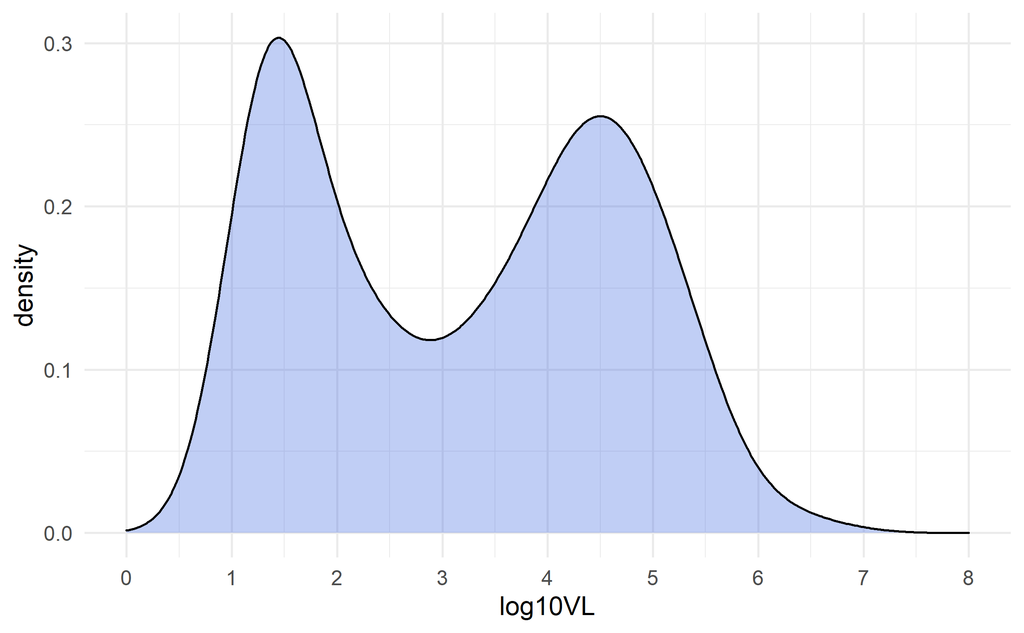

- 384 of 413 participants have a valid viral load result at T4 (93%).

# CD4

[output not shown]

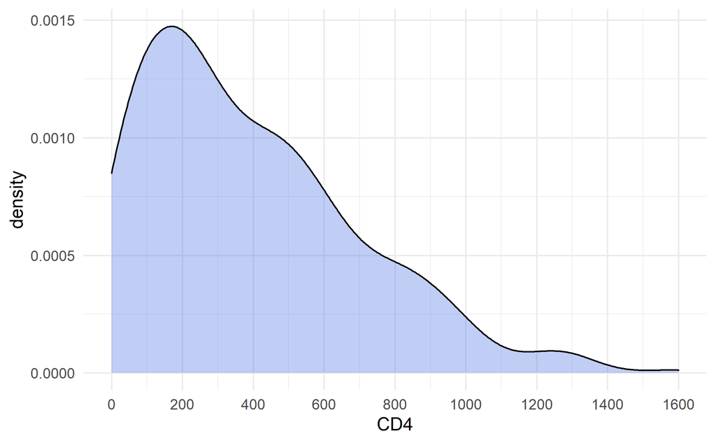

- 378 of 413 participants have a valid CD4 value at T4 (91.5%).

# CD8

| n | Mean | sd | Median | IQR | Min | Max |
| --- | --- | --- | --- | --- | --- | --- |
| 265 | 1053 | 612 | 946 | 696 | 82 | 5113 |

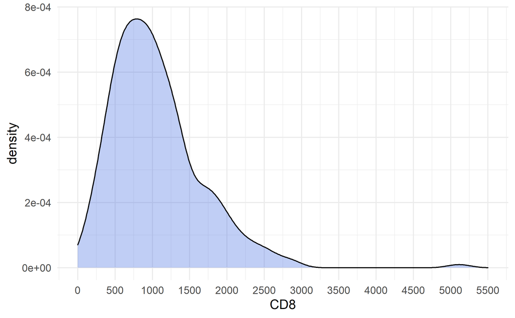

- 265 of 413 participants have a valid CD8 value at T4 (64.2%).

# CD4/CD8 Ratio

| n | Mean | sd | Median | IQR | Min | Max |
| --- | --- | --- | --- | --- | --- | --- |
| 265 | 0 | 0 | 0 | 0 | 0.0102041 | 2.302083 |

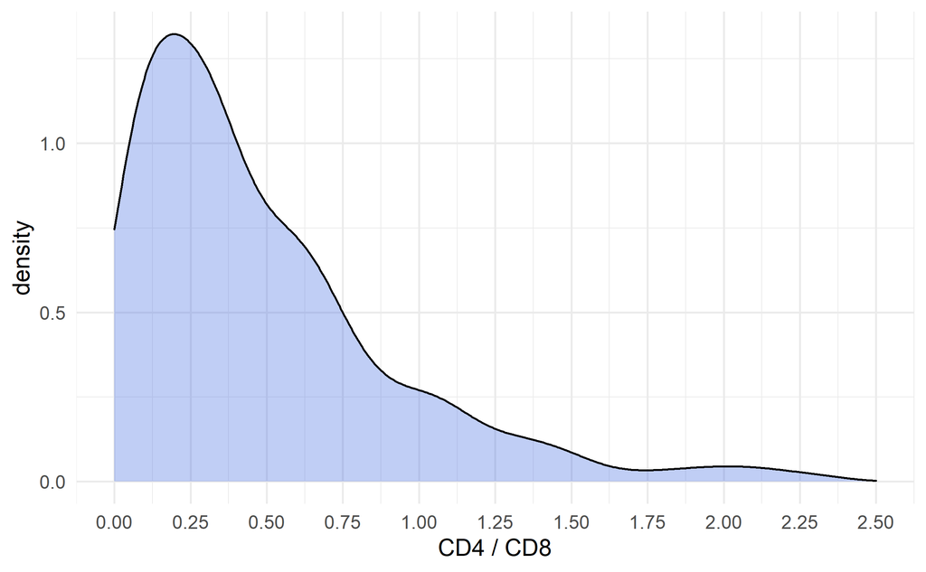